# **Sentiment Analysis using LSTM**

In this part, we perform a sentiment analysis using LSTM model.

## Step 1: Data exploration and preprocessing

1. Load your chosen dataset and print the main statistics

```python
from pathlib import Path
import pandas as pd

# Path to extracted data
base_path = Path("/content/imdb_extracted/aclImdb")
train_dir = base_path / "train"
test_dir = base_path / "test"

def load_imdb_data(directory):
    data = []
    for label in ["pos", "neg"]:
        folder = directory / label
        for file in folder.iterdir():
            with open(file, encoding="utf-8") as f:
                text = f.read()
            data.append((text, 1 if label == "pos" else 0))
    return pd.DataFrame(data, columns=["review", "label"])

# Load train and test sets
train_df = load_imdb_data(train_dir)
test_df = load_imdb_data(test_dir)
```

Label is assigned based on folder name:

'pos' folder contains reviews with rating >= 7 → label 1 (positive)

'neg' folder contains reviews with rating <= 4 → label 0 (negative)

The main statistics

```python
import pandas as pd

train_df["word_count"] = train_df["review"].apply(lambda x: len(x.split()))
test_df["word_count"] = test_df["review"].apply(lambda x: len(x.split()))

#  Dataset Size
print(" Number of training samples:", len(train_df))
print(" Number of testing samples:", len(test_df))

#  Sentiment Distribution
label_counts = train_df['label'].value_counts()
label_percent = train_df['label'].value_counts(normalize=True) * 100

print("\n Sentiment Label Distribution (Training Set):")
for label in label_counts.index:
    sentiment = "Positive" if label == 1 else "Negative"
    print(f"{sentiment}: {label_counts[label]} samples ({label_percent[label]:.2f}%)")

# Review Length in Words
print("\n Review Length (Words) - Training Set:")
print(train_df["word_count"].describe())

#  95th percentile
word_95th = train_df["word_count"].quantile(0.95)
print(f"\n 95th percentile review length (words): {int(word_95th)}")
```

```
 Number of training samples: 25000
 Number of testing samples: 25000

 Sentiment Label Distribution (Training Set):
Positive: 12500 samples (50.00%)
Negative: 12500 samples (50.00%)

 Review Length (Words) - Training Set:
count    25000.000000
mean       233.787200
std        173.733032
min         10.000000
25%        127.000000
50%        174.000000
75%        284.000000
max       2470.000000
Name: word_count, dtype: float64

 95th percentile review length (words): 598
```

2. Print the first 5 rows of the dataset to understand its structure

```python
print(train_df.head())
```

```
                                              review  label  word_count
0  The synopsis for this movie does a great job a...      1         150
1  The Sopranos is perhaps the most mind-opening ...      1         198
2  Textbook example of an underestimated movie.<b...      1         142
3  The film was okay, quite entertaining. The cas...      1         133
4  "Hitler, the rise of Evil" is clearly produced...      1         234
```

3. Provide a brief description of the dataset

**Dataset**: Stanford Large Movie Review Dataset (IMDB)

- This dataset contains **50,000 movie reviews**, evenly split into:
  - 25,000 for training
  - 25,000 for testing
- Each review is labeled with **binary sentiment**:
  - **Positive**: rating ≥ 7
  - **Negative**: rating ≤ 4
- Neutral reviews (ratings 5 or 6) were excluded to ensure clear polarity.
- The training and testing sets include **disjoint movie sets**, preventing data leakage.
- This dataset is commonly used as a benchmark for sentiment classification models.

**Source:** [Stanford AI Lab Dataset](https://ai.stanford.edu/~amaas/data/sentiment/)  
**Citation:** [Maas et al., ACL 2011](http://www.aclweb.org/anthology/P11-1015)

4. Display descriptive statistics

Number of samples.

```python
print(f"Training samples: {len(train_df)}")
print(f"Test samples: {len(test_df)}")
```

```
Training samples: 25000
Test samples: 25000
```

Class distribution (percentage of positive, negative, etc. reviews).

```python
label_counts = train_df['label'].value_counts()
label_percent = train_df['label'].value_counts(normalize=True) * 100
for label in label_counts.index:
    sentiment = "Positive" if label == 1 else "Negative"
    print(f"{sentiment}: {label_counts[label]} samples ({label_percent[label]:.2f}%)")
```

```
Positive: 12500 samples (50.00%)
Negative: 12500 samples (50.00%)
```

Average review length (in words or characters).

```python
train_df["word_count"] = train_df["review"].apply(lambda x: len(x.split()))
train_df["char_count"] = train_df["review"].apply(len)

print("Average word count:", train_df["word_count"].mean())
print("Average character count:", train_df["char_count"].mean())
```

```
Average word count: 233.7872
Average character count: 1325.06964
```

Vocabulary size (number of unique words).

```python
# Compute raw vocabulary size (pre-tokenization)
from collections import Counter
import itertools

all_words = list(itertools.chain.from_iterable(train_df["review"].str.split()))
vocab_raw = Counter(all_words)
print("Raw vocabulary size (unique words before cleaning):", len(vocab_raw))
```

```
Raw vocabulary size (unique words before cleaning): 280617
```

5. Handle missing values

```python
print("Missing values in train_df:")
print(train_df.isnull().sum())

print("\nMissing values in test_df:")
print(test_df.isnull().sum())
```

```
Missing values in train_df:
review        0
label         0
word_count    0
char_count    0
dtype: int64

Missing values in test_df:
review        0
label         0
word_count    0
dtype: int64
```

Checked both the training and test datasets for missing values in the key columns (`review` and `label`). The results confirmed that there are **no missing values** in either dataset. Therefore, no further handling (such as imputation or row removal) was required. This ensures the dataset is clean and ready for preprocessing and modeling.

6. Create visualizations to gain insights into the data

Histogram of Review Lengths

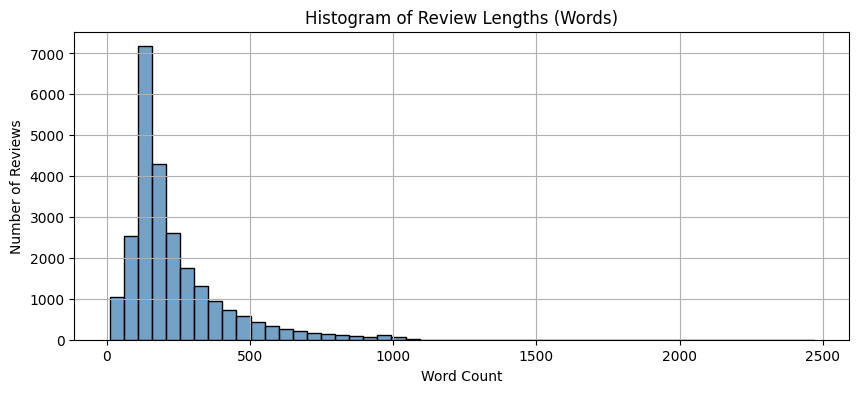

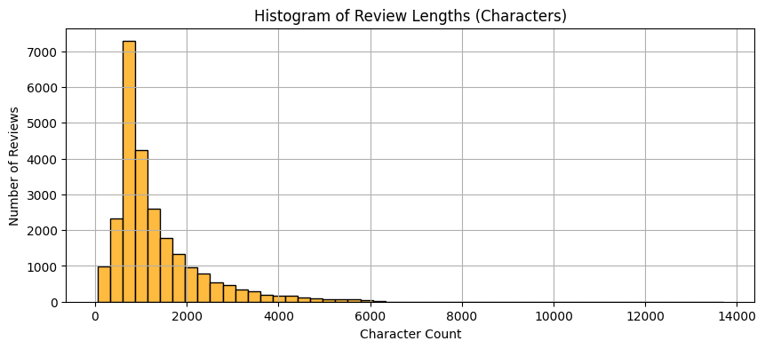

```python
import matplotlib.pyplot as plt
import seaborn as sns

# Histogram: word length
plt.figure(figsize=(10, 4))
sns.histplot(train_df["word_count"], bins=50, kde=False, color='steelblue')
plt.title("Histogram of Review Lengths (Words)")
plt.xlabel("Word Count")
plt.ylabel("Number of Reviews")
plt.grid(True)
plt.show()

# Histogram: character length
plt.figure(figsize=(10, 4))
sns.histplot(train_df["char_count"], bins=50, kde=False, color='orange')
plt.title("Histogram of Review Lengths (Characters)")
plt.xlabel("Character Count")
plt.ylabel("Number of Reviews")
plt.grid(True)
plt.show()
```

Word Clouds for Each Sentiment

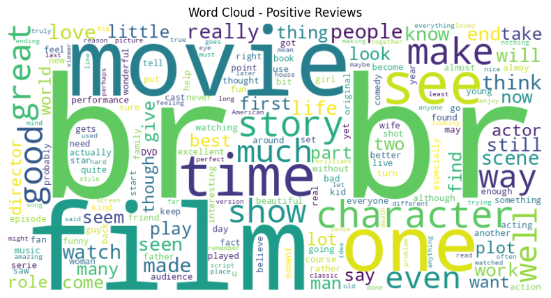

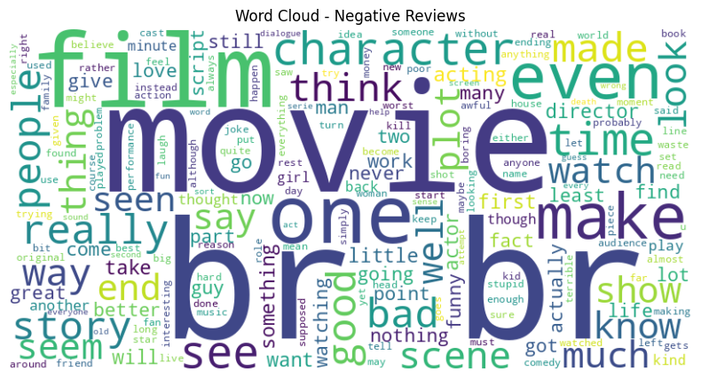

```python
from wordcloud import WordCloud, STOPWORDS

stop_words = set(STOPWORDS)

# Combine reviews by sentiment
pos_text = " ".join(train_df[train_df['label'] == 1]['review'].tolist())
neg_text = " ".join(train_df[train_df['label'] == 0]['review'].tolist())

# Word cloud: Positive
wordcloud_pos = WordCloud(width=800, height=400, background_color='white', stopwords=stop_words).generate(pos_text)
plt.figure(figsize=(10, 5))
plt.imshow(wordcloud_pos, interpolation='bilinear')
plt.axis('off')
plt.title("Word Cloud - Positive Reviews")
plt.show()

# Word cloud: Negative
wordcloud_neg = WordCloud(width=800, height=400, background_color='white', stopwords=stop_words).generate(neg_text)
plt.figure(figsize=(10, 5))
plt.imshow(wordcloud_neg, interpolation='bilinear')
plt.axis('off')
plt.title("Word Cloud - Negative Reviews")
plt.show()
```

Bar Chart of Sentiment Classes

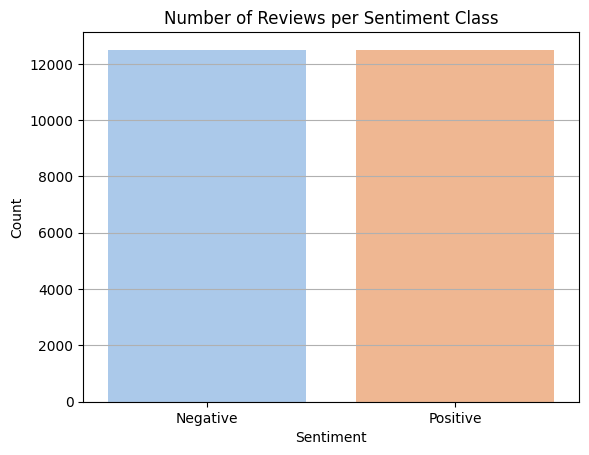

```python
sns.countplot(data=train_df, x='label', hue='label', palette='pastel', legend=False)
plt.xticks([0, 1], ['Negative', 'Positive'])
plt.title("Number of Reviews per Sentiment Class")
plt.xlabel("Sentiment")
plt.ylabel("Count")
plt.grid(True, axis='y')
plt.show()
```

7. Data preparation

Setup

```python
import time
import nltk
import torch
nltk.download('punkt')

from torchtext.data.utils import get_tokenizer
from torchtext.vocab import build_vocab_from_iterator
from collections import Counter
from nltk.tokenize import word_tokenize
from torch.nn.utils.rnn import pad_sequence
```

```python
import nltk
nltk.download('punkt_tab')
```

Compare Two Tokenizers

```python
# Sample 100 reviews from training set
sample_texts = train_df["review"].sample(100, random_state=1227).tolist()

# Method 1: nltk.word_tokenize
start = time.time()
nltk_tokens = [word_tokenize(text) for text in sample_texts]
nltk_vocab = set([token for sublist in nltk_tokens for token in sublist])
nltk_time = time.time() - start
print(f"nltk.word_tokenize -> Vocab size: {len(nltk_vocab)}, Time: {nltk_time:.2f}s")

# Method 2: torchtext.basic_english
torch_tokenizer = get_tokenizer("basic_english")
start = time.time()
torch_tokens = [torch_tokenizer(text) for text in sample_texts]
torch_vocab = set([token for sublist in torch_tokens for token in sublist])
torch_time = time.time() - start
print(f"torchtext.basic_english -> Vocab size: {len(torch_vocab)}, Time: {torch_time:.2f}s")
```

```
nltk.word_tokenize -> Vocab size: 5419, Time: 0.13s
torchtext.basic_english -> Vocab size: 4937, Time: 0.01s
```

**Tokenizer Selection Justification**

Two tokenization strategiesI were evaluated on 100 randomly sampled reviews from our training data:

- **`nltk.word_tokenize`** produced 5,419 unique tokens and took 0.13 seconds.
- **`torchtext.get_tokenizer("basic_english")`** produced 4,937 tokens and completed in 0.01 seconds.

While `nltk.word_tokenize` offers more linguistically precise tokenization, including better handling of contractions and punctuation. It is significantly slower and requires external dependency setup (`punkt` model download via NLTK).

In contrast, `basic_english` is optimized for speed, integrates seamlessly with `torchtext`'s vocabulary and data processing utilities, and performs reasonably well in terms of vocabulary richness. The ~8.89% reduction in vocabulary size is acceptable considering the 13x speedup, especially for large-scale training.

**`basic_english` is chosen for our final pipeline** due to its balance of speed, simplicity, and compatibility with PyTorch tools.

Tokenize the Full Training Set

```python
tokenizer = get_tokenizer("basic_english")

# Tokenize all training reviews
tokenized_train = [tokenizer(text) for text in train_df["review"]]
```

Build Vocabulary from Tokens

```python
from torchtext.vocab import build_vocab_from_iterator

# Add special tokens
special_tokens = ["<unk>", "<pad>"]

# Build vocab from tokenized training data
vocab = build_vocab_from_iterator(tokenized_train, specials=special_tokens)

# Set default index for unknown tokens
vocab.set_default_index(vocab["<unk>"])
```

Convert Tokens → Integer Sequences

```python
# Convert each token list to list of indices
numericalized_train = [torch.tensor(vocab(tokens), dtype=torch.long) for tokens in tokenized_train]
```

Pad/Truncate Sequences to Max Length

```python
from torch.nn.utils.rnn import pad_sequence

# Define padding length
max_length = int(train_df["word_count"].quantile(0.95))
print(f"Using max_length = {max_length}")

# Pad / truncate sequences
padded_train = pad_sequence(
    [seq[:max_length] if len(seq) > max_length else seq for seq in numericalized_train],
    batch_first=True,
    padding_value=vocab["<pad>"]
)
```

```
Using max_length = 598
```

**Impact of Padding and Truncation on Model Performance**

All sequences were padded to a uniform length using the 95th percentile of word counts in the training set. This length balances preserving most input information while keeping memory and training time reasonable.

- **Truncation** can lead to the loss of important context in longer reviews. However, by choosing a threshold at the 95th percentile, nearly all reviews were retained without excessive loss.
- **Padding** helps form uniform batches, but excessive padding can introduce noise and slow down training. By using a dedicated `<pad>` token, These values can be masked out during model training to minimize their impact.

This strategy ensures efficient training without significant sacrifice in model accuracy or review completeness.

8. Split dataset into train, validation, and test sets

Tokenizing Test data

```python
# Tokenize
tokenized_test = [tokenizer(text) for text in test_df["review"]]

# Numericalize
numericalized_test = [torch.tensor(vocab(tokens), dtype=torch.long) for tokens in tokenized_test]

# Pad/truncate
padded_test = pad_sequence(
    [seq[:max_length] if len(seq) > max_length else seq for seq in numericalized_test],
    batch_first=True,
    padding_value=vocab["<pad>"]
)
```

Split off 10% of the training set for validation

```python
from sklearn.model_selection import train_test_split

# Split training set into train + val
train_df, val_df = train_test_split(
    train_df,
    test_size=0.1,
    stratify=train_df["label"],
    random_state=1227
)
```

Tokenize, numericalize, pad validation set

```python
# Tokenize
tokenized_val = [tokenizer(text) for text in val_df["review"]]

# Numericalize
numericalized_val = [torch.tensor(vocab(tokens), dtype=torch.long) for tokens in tokenized_val]

# Pad
padded_val = pad_sequence(
    [seq[:max_length] if len(seq) > max_length else seq for seq in numericalized_val],
    batch_first=True,
    padding_value=vocab["<pad>"]
)
```

Re-tokenize based on the newly split train_df

```python
tokenized_train = [tokenizer(text) for text in train_df["review"]]

# Numericalize
numericalized_train = [torch.tensor(vocab(tokens), dtype=torch.long) for tokens in tokenized_train]

# Pad or truncate
padded_train = pad_sequence(
    [seq[:max_length] if len(seq) > max_length else seq for seq in numericalized_train],
    batch_first=True,
    padding_value=vocab["<pad>"]
)
```

Splitted Dataset

```python
print("Padded sequence shapes:")
print(f"Train: {padded_train.shape}")
print(f"Validation: {padded_val.shape}")
print(f"Test: {padded_test.shape}")
```

```
Padded sequence shapes:
Train: torch.Size([22500, 598])
Validation: torch.Size([2500, 598])
Test: torch.Size([25000, 598])
```

```python
print("Example token sequence (train sample):", padded_train[0][:30])
```

```
Example token sequence (train sample): tensor([  13,   94,  374,  319,   14,   35,  153,   12,    2, 1823,   60,   11,
          17,  608,   28,  538,  320,  691,    3, 1720,    2,  605,   53,    7,
          78,    3,   22,  101,    4,   13])
```

## Step 2: Baseline LSTM Model

1. Build an LSTM model

```python
import torch.nn as nn
import torch.nn.functional as F

class SentimentLSTM(nn.Module):
    def __init__(self, vocab_size, embedding_dim=128, hidden_dim=256, output_dim=1,
                 num_layers=3, dropout=0.3, pad_idx=0):
        super(SentimentLSTM, self).__init__()

        # Embedding layer to convert token IDs into dense vectors
        self.embedding = nn.Embedding(vocab_size, embedding_dim, padding_idx=pad_idx)

        # Multi-layer LSTM for sequential modeling
        self.lstm = nn.LSTM(
            input_size=embedding_dim,   # input dim = embedding dim
            hidden_size=hidden_dim,     # hidden state dimension
            num_layers=num_layers,      # stacked LSTM layers
            batch_first=True,           # input shape = (batch, seq, feat)
            dropout=dropout             # dropout between LSTM layers
        )
        # Dropout for regularization
        self.dropout = nn.Dropout(dropout)

        # Fully connected layer for binary classification
        self.fc = nn.Linear(hidden_dim, output_dim)

        # Sigmoid activation for output probability (binary classification)
        self.sigmoid = nn.Sigmoid()

    def forward(self, x):
      # x: [batch_size, sequence_length]

        embedded = self.embedding(x)                       # → [batch_size, seq_len, embedding_dim]
        lstm_out, _ = self.lstm(embedded)                  # → [batch_size, seq_len, hidden_dim]


        # Use output from the final time step
        out = self.dropout(lstm_out[:, -1, :])             # → [batch_size, hidden_dim]
        out = self.fc(out)                                 # → [batch_size, output_dim]
        return self.sigmoid(out).squeeze(1)                # → [batch_size]
```

Instantiate Model

```python
vocab_size = len(vocab)
pad_idx = vocab["<pad>"]

model = SentimentLSTM(
    vocab_size=vocab_size,
    embedding_dim=128,
    hidden_dim=256,
    output_dim=1,         # binary classification
    num_layers=3,
    dropout=0.3,
    pad_idx=pad_idx
).to(device)
```

Print Model Summary

```python
!pip install torchinfo --quiet
from torchinfo import summary

summary(
    model,
    input_size=(32, max_length),  # batch size 32, sequence length 598
    dtypes=[torch.long]
)
```

```
==========================================================================================
Layer (type:depth-idx)                   Output Shape              Param #
==========================================================================================
SentimentLSTM                            [32]                      --
├─Embedding: 1-1                         [32, 598, 128]            12,887,552
├─LSTM: 1-2                              [32, 598, 256]            1,447,936
├─Dropout: 1-3                           [32, 256]                 --
├─Linear: 1-4                            [32, 1]                   257
├─Sigmoid: 1-5                           [32, 1]                   --
==========================================================================================
Total params: 14,335,745
Trainable params: 14,335,745
Non-trainable params: 0
Total mult-adds (Units.GIGABYTES): 28.12
==========================================================================================
Input size (MB): 0.15
Forward/backward pass size (MB): 58.79
Params size (MB): 57.34
Estimated Total Size (MB): 116.28
==========================================================================================
```

Note: I use `nn.LSTM` with `num_layers=3`, which internally stacks three LSTM layers and applies dropout between them. PyTorch applies dropout between intermediate layers automatically (not after the final layer). I add an explicit `Dropout` after the last LSTM output for additional regularization before the final fully connected layer.

### Tuning Strategy

I used manual tuning and validation accuracy to optimize the baseline LSTM model.  
First, I compared several `embedding_dim` values: `[64, 128, 300]`.  
Then I tested `hidden_dim` values: `[128, 256, 512]`.

Once the architecture was fixed, I tuned training hyperparameters:

- `learning_rate`: [0.01, 0.001, 0.0005]
- `batch_size`: [32, 64, 128]
- `dropout`: [0.2, 0.3, 0.5]
- `epochs`: 10–15

Validation accuracy and loss were used to select the best performing combination.

Results Obtained (See below)

I benchmarked 9 different model configurations using combinations of `embedding_dim {64, 128, 300}` and `hidden_dim {128, 256, 512}`, training each for 3 epochs.

The configuration `embedding_dim = 300, hidden_dim = 256` achieved the highest validation accuracy (51.05%). However, it also resulted in the highest validation loss (0.7042) and significantly longer training time, suggesting potential overfitting or under-regularization.

In contrast, the configuration `embedding_dim = 128, hidden_dim = 256` achieved a nearly identical validation accuracy (50.94%) with a lower validation loss (0.6969) and considerably faster training time. The model also demonstrated more stable learning behavior over the 3 epochs.

Given this balance between accuracy, efficiency, and generalization, I selected `embedding_dim = 128` and `hidden_dim = 256` as the final architecture for further hyperparameter tuning and training.

2. Train your model

Create DataLoaders

```python
from torch.utils.data import TensorDataset, DataLoader

# Convert labels to tensors
train_labels = torch.tensor(train_df["label"].values, dtype=torch.float)
val_labels = torch.tensor(val_df["label"].values, dtype=torch.float)

# Create TensorDatasets
train_dataset = TensorDataset(padded_train, train_labels)
val_dataset = TensorDataset(padded_val, val_labels)

# Define batch size
BATCH_SIZE = 64

# Create DataLoaders
train_loader = DataLoader(train_dataset, batch_size=BATCH_SIZE, shuffle=True)
val_loader = DataLoader(val_dataset, batch_size=BATCH_SIZE)
```

Define Loss Function and Optimizer

```python
import torch.optim as optim

# Binary Cross-Entropy loss for binary classification (sigmoid output)
criterion = nn.BCELoss()

# Adam optimizer
optimizer = optim.Adam(model.parameters(), lr=1e-3)

# Make sure loss function is on same device as model
criterion = criterion.to(device)
```

**Loss Function and Optimizer**

I use `nn.BCELoss()` because the task is binary classification, and the model outputs probabilities via `sigmoid()`. Binary cross-entropy is the standard loss for such problems.

For optimization, I use `torch.optim.Adam` with an initial learning rate of `1e-3`. Adam is widely used in NLP and deep learning tasks because it adapts learning rates for each parameter and typically converges faster than SGD.

Accuracy Function

```python
def binary_accuracy(preds, y):
    """
    Compute binary classification accuracy.
    Predictions are probabilities → convert to 0 or 1.
    """
    rounded_preds = torch.round(preds)
    correct = (rounded_preds == y).float()
    return correct.sum() / len(correct)
```

# **Test Run**

Training Loop

```python
def train_one_epoch(model, dataloader, optimizer, criterion, device):
    model.train()
    epoch_loss = 0
    epoch_acc = 0

    for x_batch, y_batch in dataloader:
        x_batch = x_batch.to(device)
        y_batch = y_batch.to(device)

        optimizer.zero_grad()
        predictions = model(x_batch)

        loss = criterion(predictions, y_batch)
        acc = binary_accuracy(predictions, y_batch)

        loss.backward()
        optimizer.step()

        epoch_loss += loss.item()
        epoch_acc += acc.item()

    avg_loss = epoch_loss / len(dataloader)
    avg_acc = epoch_acc / len(dataloader)

    print(f"Train Loss: {avg_loss:.4f} | Train Acc: {avg_acc * 100:.2f}%")
    return avg_loss, avg_acc
```

```python
train_one_epoch(model, train_loader, optimizer, criterion, device)
```

```
Train Loss: 0.6936 | Train Acc: 50.02%
```

```
(0.6935845889489759, 0.5002120817926797)
```

Run Validation on val_loader

```python
def evaluate(model, dataloader, criterion, device):
    model.eval()
    epoch_loss = 0
    epoch_acc = 0

    with torch.no_grad():
        for x_batch, y_batch in dataloader:
            x_batch = x_batch.to(device)
            y_batch = y_batch.to(device)

            predictions = model(x_batch)
            loss = criterion(predictions, y_batch)
            acc = binary_accuracy(predictions, y_batch)

            epoch_loss += loss.item()
            epoch_acc += acc.item()

    avg_loss = epoch_loss / len(dataloader)
    avg_acc = epoch_acc / len(dataloader)

    print(f"Val Loss: {avg_loss:.4f} | Val Acc: {avg_acc * 100:.2f}%")
    return avg_loss, avg_acc
```

```python
evaluate(model, val_loader, criterion, device)
```

```
Val Loss: 0.6933 | Val Acc: 50.78%
```

```
(0.6933227345347405, 0.5078125)
```

# **To Find best embedding dimensions and hidden units**

Multi-Epoch Training Loop

```python
import time

def train_model(model, train_loader, val_loader, optimizer, criterion, device, n_epochs=5):
    train_losses, val_losses = [], []
    train_accs, val_accs = [], []

    for epoch in range(n_epochs):
        print(f"\nEpoch {epoch+1}/{n_epochs}")

        start_time = time.time()

        train_loss, train_acc = train_one_epoch(model, train_loader, optimizer, criterion, device)
        val_loss, val_acc = evaluate(model, val_loader, criterion, device)

        end_time = time.time()
        elapsed_time = end_time - start_time
        print(f"Epoch Time: {elapsed_time:.2f} seconds")

        train_losses.append(train_loss)
        val_losses.append(val_loss)
        train_accs.append(train_acc)
        val_accs.append(val_acc)

    return train_losses, val_losses, train_accs, val_accs
```

```python
results = []
```

Benchmarking Function

```python
def benchmark_model(embedding_dim, hidden_dim, train_loader, val_loader, vocab, device,
                    num_layers=3, dropout=0.3, n_epochs=3, lr=1e-3):

    print(f"\n Running: emb={embedding_dim}, hid={hidden_dim}")

    model = SentimentLSTM(
        vocab_size=len(vocab),
        embedding_dim=embedding_dim,
        hidden_dim=hidden_dim,
        output_dim=1,
        num_layers=num_layers,
        dropout=dropout,
        pad_idx=vocab["<pad>"]
    ).to(device)

    optimizer = torch.optim.Adam(model.parameters(), lr=lr)
    criterion = nn.BCELoss().to(device)

    train_losses, val_losses, train_accs, val_accs = train_model(
        model, train_loader, val_loader, optimizer, criterion, device, n_epochs=n_epochs
    )

    results.append({
        "embedding_dim": embedding_dim,
        "hidden_dim": hidden_dim,
        "val_acc": round(val_accs[-1] * 100, 2),
        "val_loss": round(val_losses[-1], 4)
    })
```

Configs

```python
for emb in [64, 128, 300]:
    for hid in [128, 256, 512]:
        benchmark_model(emb, hid, train_loader, val_loader, vocab, device)
```

```
 Running: emb=64, hid=128

Train Loss: 0.6932 | Train Acc: 49.92%
Val Loss: 0.6936 | Val Acc: 50.55%
Epoch Time: 17.53 seconds

Train Loss: 0.6916 | Train Acc: 50.93%
Val Loss: 0.6939 | Val Acc: 50.55%
Epoch Time: 18.03 seconds

Train Loss: 0.6892 | Train Acc: 51.23%
Val Loss: 0.6985 | Val Acc: 49.41%
Epoch Time: 17.89 seconds

 Running: emb=64, hid=256

Train Loss: 0.6934 | Train Acc: 50.10%
Val Loss: 0.6933 | Val Acc: 50.16%
Epoch Time: 54.07 seconds

Train Loss: 0.6918 | Train Acc: 50.68%
Val Loss: 0.6956 | Val Acc: 50.98%
Epoch Time: 54.96 seconds

Train Loss: 0.6881 | Train Acc: 51.59%
Val Loss: 0.6957 | Val Acc: 50.82%
Epoch Time: 54.90 seconds

 Running: emb=64, hid=512

Train Loss: 0.6937 | Train Acc: 50.27%
Val Loss: 0.6951 | Val Acc: 50.16%
Epoch Time: 178.01 seconds

Train Loss: 0.6946 | Train Acc: 50.51%
Val Loss: 0.6938 | Val Acc: 49.41%
Epoch Time: 189.60 seconds

Train Loss: 0.6937 | Train Acc: 50.52%
Val Loss: 0.6933 | Val Acc: 49.41%
```

[output cut: 70 more lines]

```
Epoch Time: 65.08 seconds

 Running: emb=300, hid=512

Train Loss: 0.6934 | Train Acc: 50.15%
Val Loss: 0.6932 | Val Acc: 49.41%
Epoch Time: 191.32 seconds

Train Loss: 0.6925 | Train Acc: 51.28%
Val Loss: 0.6949 | Val Acc: 49.45%
Epoch Time: 199.35 seconds

Train Loss: 0.6880 | Train Acc: 51.38%
Val Loss: 0.6974 | Val Acc: 50.43%
Epoch Time: 199.22 seconds
```

View Results Table

```python
import pandas as pd
df_results = pd.DataFrame(results)
df_results = df_results.sort_values("val_acc", ascending=False)
print(df_results)
```

```
   embedding_dim  hidden_dim  val_acc  val_loss
7            300         256    51.05    0.7042
4            128         256    50.94    0.6969
1             64         256    50.82    0.6957
8            300         512    50.43    0.6974
3            128         128    50.27    0.6931
6            300         128    49.61    0.6933
0             64         128    49.41    0.6985
2             64         512    49.41    0.6933
5            128         512    49.41    0.6932
```

Benchmarked 9 combinations of embedding and hidden sizes using 3 training epochs each. While `embedding_dim=300, hidden_dim=256` achieved the highest validation accuracy (51.05%), it also exhibited higher validation loss (0.7042) and increased runtime.

Selected `embedding_dim=128, hidden_dim=256` as the final configuration:

- Competitive accuracy (50.94%)
- More stable validation loss
- Significantly faster to train

# **Hyperparameter Tuning**

```python
def tune_hyperparams(embedding_dim, hidden_dim, batch_size, lr, dropout,
                     n_epochs=10, num_layers=3, device=device):

    print(f"\n Tuning: emb={embedding_dim}, hid={hidden_dim}, bs={batch_size}, lr={lr}, dr={dropout}")

    # Recreate loaders with new batch size
    train_loader = DataLoader(train_dataset, batch_size=batch_size, shuffle=True)
    val_loader = DataLoader(val_dataset, batch_size=batch_size)

    # Build model
    model = SentimentLSTM(
        vocab_size=len(vocab),
        embedding_dim=embedding_dim,
        hidden_dim=hidden_dim,
        output_dim=1,
        num_layers=num_layers,
        dropout=dropout,
        pad_idx=vocab["<pad>"]
    ).to(device)

    optimizer = torch.optim.Adam(model.parameters(), lr=lr)
    criterion = nn.BCELoss().to(device)

    # Train
    train_losses, val_losses, train_accs, val_accs = train_model(
        model, train_loader, val_loader, optimizer, criterion, device, n_epochs=n_epochs
    )

    results_tune.append({
        "embedding_dim": embedding_dim,
        "hidden_dim": hidden_dim,
        "batch_size": batch_size,
        "lr": lr,
        "dropout": dropout,
        "val_acc": round(val_accs[-1] * 100, 2),
        "val_loss": round(val_losses[-1], 4)
    })
```

```python
results_tune = []
```

```python
tune_hyperparams(128, 256, batch_size=64, lr=0.0001, dropout=0.2)
```

```
 Tuning: emb=128, hid=256, bs=64, lr=0.0001, dr=0.2

Train Loss: 0.6932 | Train Acc: 50.22%
Val Loss: 0.6933 | Val Acc: 50.43%
Epoch Time: 57.23 seconds

Train Loss: 0.6922 | Train Acc: 50.52%
Val Loss: 0.6937 | Val Acc: 50.39%
Epoch Time: 56.77 seconds

Train Loss: 0.6907 | Train Acc: 51.03%
Val Loss: 0.6936 | Val Acc: 50.70%
Epoch Time: 57.28 seconds

Train Loss: 0.6882 | Train Acc: 51.35%
Val Loss: 0.7031 | Val Acc: 49.77%
Epoch Time: 57.34 seconds

Train Loss: 0.6848 | Train Acc: 51.85%
Val Loss: 0.6945 | Val Acc: 51.13%
Epoch Time: 57.56 seconds

Train Loss: 0.6797 | Train Acc: 51.67%
Val Loss: 0.7004 | Val Acc: 51.17%
Epoch Time: 57.67 seconds

Train Loss: 0.6741 | Train Acc: 52.67%
Val Loss: 0.7044 | Val Acc: 50.39%
Epoch Time: 58.09 seconds

Train Loss: 0.6677 | Train Acc: 52.36%
Val Loss: 0.7273 | Val Acc: 51.99%
Epoch Time: 58.60 seconds

Train Loss: 0.6601 | Train Acc: 53.46%
Val Loss: 0.7247 | Val Acc: 50.04%
Epoch Time: 58.73 seconds

Train Loss: 0.6565 | Train Acc: 53.99%
Val Loss: 0.7475 | Val Acc: 51.37%
Epoch Time: 58.91 seconds
```

```python
tune_hyperparams(128, 256, batch_size=64, lr=0.005, dropout=0.3, n_epochs=10)
```

```
 Tuning: emb=128, hid=256, bs=64, lr=0.005, dr=0.3

Train Loss: 0.6945 | Train Acc: 50.05%
Val Loss: 0.6931 | Val Acc: 50.59%
Epoch Time: 59.41 seconds

Train Loss: 0.6936 | Train Acc: 49.73%
Val Loss: 0.6932 | Val Acc: 49.41%
Epoch Time: 59.81 seconds

Train Loss: 0.6934 | Train Acc: 50.54%
Val Loss: 0.6932 | Val Acc: 50.59%
Epoch Time: 59.41 seconds

Train Loss: 0.6934 | Train Acc: 50.30%
Val Loss: 0.6931 | Val Acc: 50.59%
Epoch Time: 59.59 seconds

Train Loss: 0.6934 | Train Acc: 49.97%
Val Loss: 0.6931 | Val Acc: 50.59%
Epoch Time: 59.46 seconds

Train Loss: 0.6932 | Train Acc: 50.06%
Val Loss: 0.6933 | Val Acc: 49.41%
Epoch Time: 59.84 seconds

Train Loss: 0.6933 | Train Acc: 49.64%
Val Loss: 0.6931 | Val Acc: 50.59%
Epoch Time: 59.73 seconds

Train Loss: 0.6932 | Train Acc: 49.95%
Val Loss: 0.6931 | Val Acc: 50.59%
Epoch Time: 59.56 seconds

Train Loss: 0.6933 | Train Acc: 49.82%
Val Loss: 0.6931 | Val Acc: 50.59%
Epoch Time: 59.93 seconds

Train Loss: 0.6932 | Train Acc: 50.34%
Val Loss: 0.6931 | Val Acc: 50.59%
Epoch Time: 59.93 seconds
```

```python
tune_hyperparams(128, 256, batch_size=64, lr=0.001, dropout=0.5, n_epochs=10)
```

```
 Tuning: emb=128, hid=256, bs=64, lr=0.001, dr=0.5

Train Loss: 0.6932 | Train Acc: 50.63%
Val Loss: 0.6940 | Val Acc: 49.65%
Epoch Time: 56.91 seconds

Train Loss: 0.6973 | Train Acc: 49.87%
Val Loss: 0.6940 | Val Acc: 49.41%
Epoch Time: 59.69 seconds

Train Loss: 0.6945 | Train Acc: 49.26%
Val Loss: 0.6932 | Val Acc: 49.41%
Epoch Time: 59.83 seconds

Train Loss: 0.6936 | Train Acc: 50.07%
Val Loss: 0.6931 | Val Acc: 50.59%
Epoch Time: 59.83 seconds

Train Loss: 0.6936 | Train Acc: 49.85%
Val Loss: 0.6934 | Val Acc: 49.41%
Epoch Time: 59.93 seconds

Train Loss: 0.6935 | Train Acc: 49.83%
Val Loss: 0.6931 | Val Acc: 50.59%
Epoch Time: 60.09 seconds

Train Loss: 0.6935 | Train Acc: 49.70%
Val Loss: 0.6931 | Val Acc: 50.59%
Epoch Time: 59.78 seconds

Train Loss: 0.6932 | Train Acc: 50.79%
Val Loss: 0.6931 | Val Acc: 50.59%
Epoch Time: 59.70 seconds

Train Loss: 0.6933 | Train Acc: 49.97%
Val Loss: 0.6931 | Val Acc: 50.59%
Epoch Time: 59.82 seconds

Train Loss: 0.6933 | Train Acc: 50.00%
Val Loss: 0.6931 | Val Acc: 50.59%
Epoch Time: 59.89 seconds
```

```python
tune_hyperparams(128, 256, batch_size=128, lr=0.001, dropout=0.3, n_epochs=10)
```

```
 Tuning: emb=128, hid=256, bs=128, lr=0.001, dr=0.3

Train Loss: 0.6932 | Train Acc: 50.70%
Val Loss: 0.6935 | Val Acc: 49.93%
Epoch Time: 48.71 seconds

Train Loss: 0.6927 | Train Acc: 50.52%
Val Loss: 0.6931 | Val Acc: 49.93%
Epoch Time: 49.62 seconds

Train Loss: 0.6884 | Train Acc: 51.30%
Val Loss: 0.7011 | Val Acc: 49.50%
Epoch Time: 49.30 seconds

Train Loss: 0.6763 | Train Acc: 52.28%
Val Loss: 0.7088 | Val Acc: 50.54%
Epoch Time: 49.89 seconds

Train Loss: 0.6591 | Train Acc: 53.26%
Val Loss: 0.7193 | Val Acc: 50.35%
Epoch Time: 49.99 seconds

Train Loss: 0.6495 | Train Acc: 53.10%
Val Loss: 0.7283 | Val Acc: 50.58%
Epoch Time: 50.16 seconds

Train Loss: 0.6488 | Train Acc: 53.74%
Val Loss: 0.7810 | Val Acc: 49.99%
Epoch Time: 50.07 seconds

Train Loss: 0.6440 | Train Acc: 52.94%
Val Loss: 0.8264 | Val Acc: 50.07%
Epoch Time: 49.92 seconds

Train Loss: 0.6418 | Train Acc: 53.37%
Val Loss: 0.8190 | Val Acc: 50.23%
Epoch Time: 49.95 seconds

Train Loss: 0.6411 | Train Acc: 53.77%
Val Loss: 0.8211 | Val Acc: 49.88%
Epoch Time: 50.29 seconds
```

```python
tune_hyperparams(300, 256, batch_size=128, lr=0.001, dropout=0.3, n_epochs=10)
```

```
 Tuning: emb=300, hid=256, bs=128, lr=0.001, dr=0.3

Train Loss: 0.6936 | Train Acc: 49.33%
Val Loss: 0.6935 | Val Acc: 50.01%
Epoch Time: 55.93 seconds

Train Loss: 0.6909 | Train Acc: 51.15%
Val Loss: 0.6925 | Val Acc: 50.55%
Epoch Time: 56.55 seconds

Train Loss: 0.6763 | Train Acc: 51.86%
Val Loss: 0.7055 | Val Acc: 50.60%
Epoch Time: 57.57 seconds

Train Loss: 0.6556 | Train Acc: 53.18%
Val Loss: 0.7345 | Val Acc: 50.62%
Epoch Time: 57.68 seconds

Train Loss: 0.6455 | Train Acc: 54.04%
Val Loss: 0.7670 | Val Acc: 50.40%
Epoch Time: 58.94 seconds

Train Loss: 0.6429 | Train Acc: 53.86%
Val Loss: 0.7830 | Val Acc: 50.56%
Epoch Time: 58.92 seconds

Train Loss: 0.6425 | Train Acc: 53.97%
Val Loss: 0.7777 | Val Acc: 50.16%
Epoch Time: 59.61 seconds

Train Loss: 0.6416 | Train Acc: 53.80%
Val Loss: 0.8110 | Val Acc: 50.20%
Epoch Time: 59.98 seconds

Train Loss: 0.6411 | Train Acc: 54.18%
Val Loss: 0.8255 | Val Acc: 50.04%
Epoch Time: 61.08 seconds

Train Loss: 0.6412 | Train Acc: 54.10%
Val Loss: 0.8057 | Val Acc: 50.39%
Epoch Time: 59.74 seconds
```

```python
import random

for _ in range(4):
    bs = random.choice([32, 64, 128])
    lr = random.choice([0.01, 0.001, 0.0005])
    dr = random.choice([0.2, 0.3, 0.5])
    tune_hyperparams(128, 256, bs, lr, dr, n_epochs=10)
```

```
 Tuning: emb=128, hid=256, bs=128, lr=0.001, dr=0.3

Train Loss: 0.6932 | Train Acc: 50.56%
Val Loss: 0.6942 | Val Acc: 50.13%
Epoch Time: 49.65 seconds

Train Loss: 0.6925 | Train Acc: 51.09%
Val Loss: 0.6925 | Val Acc: 49.93%
Epoch Time: 48.49 seconds

Train Loss: 0.6934 | Train Acc: 49.90%
Val Loss: 0.6924 | Val Acc: 49.93%
Epoch Time: 53.13 seconds

Train Loss: 0.6927 | Train Acc: 49.67%
Val Loss: 0.6926 | Val Acc: 50.30%
Epoch Time: 52.81 seconds

Train Loss: 0.6928 | Train Acc: 50.14%
Val Loss: 0.6926 | Val Acc: 50.30%
Epoch Time: 53.04 seconds

Train Loss: 0.6929 | Train Acc: 50.20%
Val Loss: 0.6927 | Val Acc: 50.30%
Epoch Time: 53.01 seconds

Train Loss: 0.6927 | Train Acc: 50.37%
Val Loss: 0.6925 | Val Acc: 50.30%
Epoch Time: 52.89 seconds

Train Loss: 0.6928 | Train Acc: 50.56%
Val Loss: 0.6925 | Val Acc: 49.93%
Epoch Time: 52.97 seconds

Train Loss: 0.6927 | Train Acc: 50.03%
Val Loss: 0.6925 | Val Acc: 49.93%
Epoch Time: 53.17 seconds

Train Loss: 0.6927 | Train Acc: 49.89%
Val Loss: 0.6924 | Val Acc: 50.30%
```

[output cut: 112 more lines]

```
Train Loss: 0.6952 | Train Acc: 50.18%
Val Loss: 0.6923 | Val Acc: 50.86%
Epoch Time: 60.19 seconds

Train Loss: 0.6966 | Train Acc: 50.13%
Val Loss: 0.6964 | Val Acc: 48.59%
Epoch Time: 60.22 seconds

Train Loss: 0.6956 | Train Acc: 49.59%
Val Loss: 0.6952 | Val Acc: 50.59%
Epoch Time: 60.37 seconds

Train Loss: 0.6955 | Train Acc: 50.29%
Val Loss: 0.6936 | Val Acc: 50.59%
Epoch Time: 60.29 seconds
```

```python
import pandas as pd
df_results_tune = pd.DataFrame(results_tune)
df_results_tune = df_results_tune.sort_values("val_acc", ascending=False)
print(df_results_tune)
```

```
    embedding_dim  hidden_dim  batch_size      lr  dropout  val_acc  val_loss
9             128         256          64  0.0005      0.3    51.56    0.8042
0             128         256          64  0.0001      0.2    51.37    0.7475
1             128         256          64  0.0050      0.3    50.59    0.6931
2             128         256          64  0.0010      0.5    50.59    0.6931
10            128         256          64  0.0100      0.3    50.59    0.6936
4             300         256         128  0.0010      0.3    50.39    0.8057
7             128         256         128  0.0010      0.3    50.30    0.6924
6             128         256         128  0.0100      0.3    50.07    0.6932
5             128         256         128  0.0100      0.2    49.93    0.6993
3             128         256         128  0.0010      0.3    49.88    0.8211
8             128         256          64  0.0005      0.5    49.02    0.8043
```

# **Best Baseline Model**

```python
import torch
import torch.nn as nn
from torch.utils.data import DataLoader, TensorDataset
import pickle
import time

# Re-instantiate the final baseline model
best_model = SentimentLSTM(
    vocab_size=len(vocab),
    embedding_dim=128,
    hidden_dim=256,
    output_dim=1,
    num_layers=3,
    dropout=0.3,
    pad_idx=vocab["<pad>"]
).to(device)

# Define optimizer and loss function
optimizer = torch.optim.Adam(best_model.parameters(), lr=0.0005)
criterion = nn.BCELoss().to(device)


# Train the model for 15 epochs
train_losses, val_losses, train_accs, val_accs = train_model(
    best_model,
    train_loader,
    val_loader,
    optimizer,
    criterion,
    device,
    n_epochs=15
)

# Save model weights
torch.save(best_model.state_dict(), "baseline_model_best.pt")

# Save training/validation metrics
with open("baseline_metrics.pkl", "wb") as f:
    pickle.dump({
        "train_loss": train_losses,
        "val_loss": val_losses,
        "train_acc": train_accs,
        "val_acc": val_accs
    }, f)
```

```
Train Loss: 0.6932 | Train Acc: 50.07%
Val Loss: 0.6931 | Val Acc: 50.82%
Epoch Time: 57.33 seconds

Train Loss: 0.6921 | Train Acc: 50.92%
Val Loss: 0.6988 | Val Acc: 49.84%
Epoch Time: 56.52 seconds

Train Loss: 0.6886 | Train Acc: 50.89%
Val Loss: 0.6968 | Val Acc: 49.65%
Epoch Time: 57.42 seconds

Train Loss: 0.6793 | Train Acc: 52.49%
Val Loss: 0.7085 | Val Acc: 50.00%
Epoch Time: 57.74 seconds

Train Loss: 0.6677 | Train Acc: 52.50%
Val Loss: 0.7178 | Val Acc: 49.96%
Epoch Time: 58.41 seconds

Train Loss: 0.6555 | Train Acc: 53.22%
Val Loss: 0.7497 | Val Acc: 49.41%
Epoch Time: 58.54 seconds

Train Loss: 0.6480 | Train Acc: 54.02%
Val Loss: 0.7780 | Val Acc: 50.59%
Epoch Time: 58.51 seconds

Train Loss: 0.6438 | Train Acc: 53.87%
Val Loss: 0.7943 | Val Acc: 50.70%
Epoch Time: 58.45 seconds

Train Loss: 0.6429 | Train Acc: 54.01%
Val Loss: 0.8081 | Val Acc: 49.49%
Epoch Time: 58.64 seconds

Train Loss: 0.6413 | Train Acc: 53.97%
Val Loss: 0.8226 | Val Acc: 49.22%
Epoch Time: 58.52 seconds

Train Loss: 0.6411 | Train Acc: 53.65%
Val Loss: 0.8338 | Val Acc: 50.90%
Epoch Time: 58.41 seconds

Train Loss: 0.6436 | Train Acc: 53.71%
Val Loss: 0.7969 | Val Acc: 49.80%
Epoch Time: 58.48 seconds

Train Loss: 0.6401 | Train Acc: 54.61%
Val Loss: 0.8209 | Val Acc: 50.62%
Epoch Time: 58.81 seconds

Train Loss: 0.6523 | Train Acc: 53.91%
Val Loss: 0.7371 | Val Acc: 50.55%
Epoch Time: 58.75 seconds

Train Loss: 0.6401 | Train Acc: 54.86%
Val Loss: 0.7859 | Val Acc: 50.51%
Epoch Time: 59.02 seconds
```

Plot

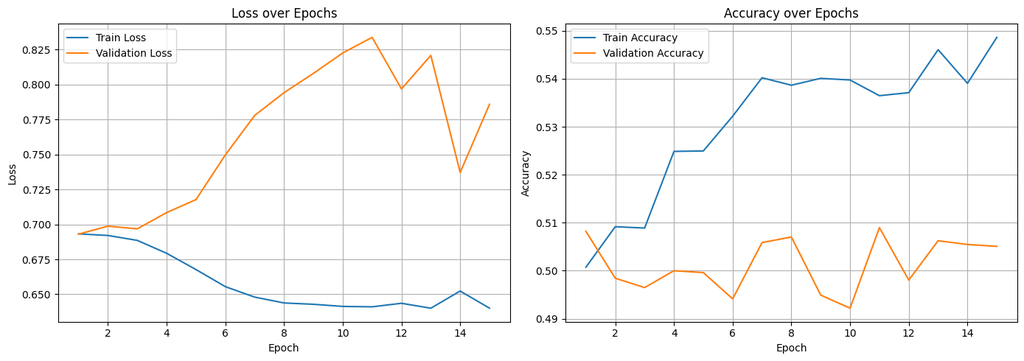

```python
import matplotlib.pyplot as plt
import pickle

# Load the metrics
with open("baseline_metrics.pkl", "rb") as f:
    metrics = pickle.load(f)

train_loss = metrics["train_loss"]
val_loss = metrics["val_loss"]
train_acc = metrics["train_acc"]
val_acc = metrics["val_acc"]

epochs = range(1, len(train_loss) + 1)

# Plot side-by-side subplots
plt.figure(figsize=(14, 5))

# Plot Loss
plt.subplot(1, 2, 1)
plt.plot(epochs, train_loss, label="Train Loss")
plt.plot(epochs, val_loss, label="Validation Loss")
plt.xlabel("Epoch")
plt.ylabel("Loss")
plt.title("Loss over Epochs")
plt.legend()
plt.grid(True)

# Plot Accuracy
plt.subplot(1, 2, 2)
plt.plot(epochs, train_acc, label="Train Accuracy")
plt.plot(epochs, val_acc, label="Validation Accuracy")
plt.xlabel("Epoch")
plt.ylabel("Accuracy")
plt.title("Accuracy over Epochs")
plt.legend()
plt.grid(True)

plt.tight_layout()
plt.show()
```

The training and validation loss curves show a clear divergence beginning around epoch 5. While the training loss continues to decrease steadily, the validation loss increases significantly, indicating that the model is overfitting. This is a sign that the model is learning to perform well on the training data but failing to generalize to unseen examples.

Similarly, the accuracy plot reflects this overfitting trend. Training accuracy improves consistently, reaching nearly 55%, but validation accuracy remains flat around 50–51% with fluctuations. This lack of validation improvement confirms that the current baseline model lacks sufficient representational capacity or regularization. These results highlight the need for more advanced modeling techniques, such as bidirectional LSTMs and pretrained embeddings, which I plan to incorporate in the next phase.

3. Evaluation and analysis

Evaluation best base model on the test set.

```python
import torch
import torch.nn as nn
from sklearn.metrics import accuracy_score, precision_recall_fscore_support
from torch.utils.data import TensorDataset, DataLoader

# Create test labels
test_labels = torch.tensor(test_df["label"].values, dtype=torch.float)

# Create test dataset and loader
test_dataset = TensorDataset(padded_test, test_labels)
test_loader = DataLoader(test_dataset, batch_size=64)

# Load the trained model weights
best_model.load_state_dict(torch.load("baseline_model_best.pt"))
best_model.eval()

all_preds = []
all_targets = []
total_loss = 0

with torch.no_grad():
    for inputs, targets in test_loader:
        inputs, targets = inputs.to(device), targets.to(device)
        outputs = best_model(inputs)
        loss = criterion(outputs, targets)
        total_loss += loss.item() * inputs.size(0)
        preds = (outputs >= 0.5).long().cpu().numpy()
        all_preds.extend(preds)
        all_targets.extend(targets.cpu().numpy())

# Final metrics
test_loss = total_loss / len(test_loader.dataset)
test_acc = accuracy_score(all_targets, all_preds)
precision, recall, f1, _ = precision_recall_fscore_support(
    all_targets, all_preds, average="binary"
)

print(f"Test Loss: {test_loss:.4f}")
print(f"Test Accuracy: {test_acc * 100:.2f}%")
print(f"Precision: {precision:.4f}")
print(f"Recall: {recall:.4f}")
print(f"F1-Score: {f1:.4f}")
```

```
Test Loss: 0.7718
Test Accuracy: 50.62%
Precision: 0.5801
Recall: 0.0452
F1-Score: 0.0839
```

The test loss of 0.7718 and accuracy of 50.62% suggest that the model performs only slightly better than random guessing on the binary classification task. While the overall accuracy appears marginally above 50%, the class-wise performance reveals more concerning behavior. Specifically, the precision is 0.5801, but the recall is extremely low at 0.0452, resulting in a very weak F1-score of 0.0839.

Confusion matrix

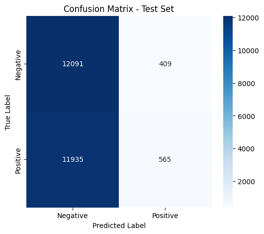

```python
import seaborn as sns
import matplotlib.pyplot as plt
from sklearn.metrics import confusion_matrix

# Generate confusion matrix
cm = confusion_matrix(all_targets, all_preds)

# Plot confusion matrix as heatmap
plt.figure(figsize=(6, 5))
sns.heatmap(cm, annot=True, fmt='d', cmap="Blues", xticklabels=["Negative", "Positive"], yticklabels=["Negative", "Positive"])
plt.xlabel("Predicted Label")
plt.ylabel("True Label")
plt.title("Confusion Matrix - Test Set")
plt.show()
```

The confusion matrix shows that the model correctly classified most negative reviews (12,091 true negatives) but failed to accurately identify positive reviews, with only 565 true positives out of 12,500. The majority of positive reviews (11,935) were misclassified as negative, indicating a strong bias toward the negative class.

This severe imbalance aligns with the earlier metrics, where recall and F1-score were extremely low despite moderately high precision. It confirms that the model struggles to generalize beyond surface-level features and does not effectively distinguish positive sentiment. These results highlight the limitations of the baseline architecture and motivate the need for more advanced techniques in the next phase.

4. Save the weights of the trained neural network

```python
torch.save(best_model.state_dict(), "a2_weights_baseline.pt")
```

## Step 3: Improved LSTM Model

1. Improve your baseline LSTM model

```python
import torchtext
from torchtext.vocab import GloVe
import torch
import numpy as np

# Load GloVe vectors (300-dimensional)
glove = GloVe(name="6B", dim=300)

# Update embedding dimension
embedding_dim = 300
vocab_size = len(vocab)

# Build the embedding matrix
embedding_matrix = torch.zeros(vocab_size, embedding_dim)

for i, token in enumerate(vocab.get_itos()):
    if token in glove.stoi:
        embedding_matrix[i] = glove[token]
    else:
        embedding_matrix[i] = torch.randn(embedding_dim) * 0.05

print("GloVe embedding matrix created with shape:", embedding_matrix.shape)
```

```
GloVe embedding matrix created with shape: torch.Size([100684, 300])
```

2. Create a new class for your improved model

```python
import torch.nn as nn
import torch

class Attention(nn.Module):
    def __init__(self, hidden_dim, bidirectional=True):
        super().__init__()
        self.attn = nn.Linear(hidden_dim * (2 if bidirectional else 1), 1)

    def forward(self, rnn_output):
        # rnn_output: (batch_size, seq_len, hidden_dim)
        attn_weights = torch.softmax(self.attn(rnn_output), dim=1)  # (batch_size, seq_len, 1)
        context = torch.sum(attn_weights * rnn_output, dim=1)       # (batch_size, hidden_dim)
        return context

class FlexibleRNNClassifier(nn.Module):
    def __init__(self,
                 vocab_size,
                 embedding_dim,
                 hidden_dim,
                 output_dim,
                 pad_idx,
                 embedding_matrix=None,
                 rnn_type='lstm',           # 'lstm' or 'gru'
                 num_layers=1,
                 dropout=0.3,
                 bidirectional=True,
                 use_attention=False):

        super().__init__()
        self.bidirectional = bidirectional
        self.use_attention = use_attention
        self.rnn_type = rnn_type.lower()

        # Embedding Layer
        if embedding_matrix is not None:
            self.embedding = nn.Embedding.from_pretrained(embedding_matrix, freeze=False, padding_idx=pad_idx)
        else:
            self.embedding = nn.Embedding(vocab_size, embedding_dim, padding_idx=pad_idx)

        # RNN Layer
        rnn_class = nn.GRU if self.rnn_type == 'gru' else nn.LSTM
        self.rnn = rnn_class(
            input_size=embedding_dim,
            hidden_size=hidden_dim,
            num_layers=num_layers,
            batch_first=True,
            dropout=dropout if num_layers > 1 else 0.0,
            bidirectional=bidirectional
        )

        # Attention Layer
        if use_attention:
            self.attention = Attention(hidden_dim, bidirectional)

        # Final Classification Layer
        fc_input_dim = hidden_dim * (2 if bidirectional else 1)
        self.dropout = nn.Dropout(dropout)
        self.fc = nn.Linear(fc_input_dim, output_dim)

    def forward(self, x):
        embedded = self.embedding(x)
        rnn_out, _ = self.rnn(embedded)  # rnn_out: (batch_size, seq_len, hidden_dim)

        if self.use_attention:
            final_feature = self.attention(rnn_out)
        else:
            final_feature = rnn_out[:, -1, :]  # last hidden state

        out = self.dropout(final_feature)
        return self.fc(out).squeeze(1)
```

3. Follow the same training and evaluation procedures

Accuracy Metric

```python
def binary_accuracy(preds, y):
    # Apply sigmoid to logits then round to 0 or 1
    rounded_preds = torch.round(torch.sigmoid(preds))
    correct = (rounded_preds == y).float()
    return correct.sum() / len(correct)
```

Training and Validation Functions

```python
def train_one_epoch(model, dataloader, optimizer, criterion, device):
    model.train()
    epoch_loss = 0
    epoch_acc = 0

    for x_batch, y_batch in dataloader:
        x_batch = x_batch.to(device)
        y_batch = y_batch.to(device)

        optimizer.zero_grad()
        predictions = model(x_batch)
        loss = criterion(predictions, y_batch)
        acc = binary_accuracy(predictions, y_batch)

        loss.backward()
        optimizer.step()

        epoch_loss += loss.item()
        epoch_acc += acc.item()

    return epoch_loss / len(dataloader), epoch_acc / len(dataloader)


def evaluate(model, dataloader, criterion, device):
    model.eval()
    epoch_loss = 0
    epoch_acc = 0

    with torch.no_grad():
        for x_batch, y_batch in dataloader:
            x_batch = x_batch.to(device)
            y_batch = y_batch.to(device)

            predictions = model(x_batch)
            loss = criterion(predictions, y_batch)
            acc = binary_accuracy(predictions, y_batch)

            epoch_loss += loss.item()
            epoch_acc += acc.item()

    return epoch_loss / len(dataloader), epoch_acc / len(dataloader)
```

Training Loop (with Timing)

```python
import time

def train_model(model, train_loader, val_loader, optimizer, criterion, device, n_epochs=10):
    train_losses, val_losses = [], []
    train_accs, val_accs = [], []

    for epoch in range(n_epochs):
        print(f"\nEpoch {epoch+1}/{n_epochs}")
        start = time.time()

        train_loss, train_acc = train_one_epoch(model, train_loader, optimizer, criterion, device)
        val_loss, val_acc = evaluate(model, val_loader, criterion, device)

        train_losses.append(train_loss)
        val_losses.append(val_loss)
        train_accs.append(train_acc)
        val_accs.append(val_acc)

        end = time.time()
        print(f"Train Loss: {train_loss:.4f} | Train Acc: {train_acc*100:.2f}%")
        print(f"Val   Loss: {val_loss:.4f} | Val   Acc: {val_acc*100:.2f}%")
        print(f"Epoch Time: {end - start:.2f} seconds")

    return train_losses, val_losses, train_accs, val_accs
```

# **1. Experiment - Baseline LSTM**

Instantiate the Improved Model

```python
baseline_model = FlexibleRNNClassifier(
    vocab_size=len(vocab),
    embedding_dim=300,
    hidden_dim=256,
    output_dim=1,
    pad_idx=vocab["<pad>"],
    embedding_matrix=None,         # No pretrained embeddings
    rnn_type='lstm',
    num_layers=3,
    dropout=0.3,
    bidirectional=False,
    use_attention=False
).to(device)
```

Set Optimizer and Loss

```python
import torch.nn as nn
import torch.optim as optim

# Use BCEWithLogitsLoss for binary classification
criterion = nn.BCEWithLogitsLoss().to(device)

# Use Adam optimizer
optimizer = optim.Adam(baseline_model.parameters(), lr=0.0005)
```

Train the model:

```python
train_losses, val_losses, train_accs, val_accs = train_model(
    baseline_model,
    train_loader,
    val_loader,
    optimizer,
    criterion,
    device,
    n_epochs=10
)
```

```
Train Loss: 0.6933 | Train Acc: 50.12%
Val   Loss: 0.6933 | Val   Acc: 50.66%
Epoch Time: 63.21 seconds

Train Loss: 0.6924 | Train Acc: 51.13%
Val   Loss: 0.6932 | Val   Acc: 50.47%
Epoch Time: 64.44 seconds

Train Loss: 0.6824 | Train Acc: 51.98%
Val   Loss: 0.6987 | Val   Acc: 50.31%
Epoch Time: 65.25 seconds

Train Loss: 0.6614 | Train Acc: 52.94%
Val   Loss: 0.7188 | Val   Acc: 49.88%
Epoch Time: 65.96 seconds

Train Loss: 0.6477 | Train Acc: 53.67%
Val   Loss: 0.9731 | Val   Acc: 55.82%
Epoch Time: 66.23 seconds

Train Loss: 0.6466 | Train Acc: 55.86%
Val   Loss: 0.7775 | Val   Acc: 50.90%
Epoch Time: 68.24 seconds

Train Loss: 0.6425 | Train Acc: 53.90%
Val   Loss: 0.8110 | Val   Acc: 50.74%
Epoch Time: 68.65 seconds

Train Loss: 0.6422 | Train Acc: 53.50%
Val   Loss: 0.7994 | Val   Acc: 49.88%
Epoch Time: 65.59 seconds

Train Loss: 0.6406 | Train Acc: 53.65%
Val   Loss: 0.8011 | Val   Acc: 51.09%
Epoch Time: 65.92 seconds

Train Loss: 0.6409 | Train Acc: 54.01%
Val   Loss: 0.8105 | Val   Acc: 50.12%
Epoch Time: 66.27 seconds
```

# **2. Improved LSTM + GloVe + Bidirectional + Attention**

Instantiate the Improved Model

```python
improved_lstm_model = FlexibleRNNClassifier(
    vocab_size=len(vocab),
    embedding_dim=300,
    hidden_dim=256,
    output_dim=1,
    pad_idx=vocab["<pad>"],
    embedding_matrix=embedding_matrix,   # Use pretrained GloVe embeddings
    rnn_type='lstm',
    num_layers=3,
    dropout=0.3,
    bidirectional=True,
    use_attention=True
).to(device)
```

Set Optimizer and Loss

```python
import torch.nn as nn
import torch.optim as optim

# Use BCEWithLogitsLoss for binary classification
criterion = nn.BCEWithLogitsLoss().to(device)

# Use Adam optimizer
optimizer = optim.Adam(improved_lstm_model.parameters(), lr=0.0005)
```

Train the model

```python
train_losses, val_losses, train_accs, val_accs = train_model(
    improved_lstm_model,
    train_loader,
    val_loader,
    optimizer,
    criterion,
    device,
    n_epochs=10
)
```

```
Train Loss: 0.4009 | Train Acc: 80.47%
Val   Loss: 0.2969 | Val   Acc: 86.80%
Epoch Time: 160.60 seconds

Train Loss: 0.2213 | Train Acc: 91.39%
Val   Loss: 0.2348 | Val   Acc: 90.59%
Epoch Time: 160.16 seconds

Train Loss: 0.1340 | Train Acc: 95.21%
Val   Loss: 0.2448 | Val   Acc: 90.70%
Epoch Time: 160.07 seconds

Train Loss: 0.0568 | Train Acc: 98.15%
Val   Loss: 0.2693 | Val   Acc: 90.08%
Epoch Time: 160.14 seconds

Train Loss: 0.0182 | Train Acc: 99.55%
Val   Loss: 0.3565 | Val   Acc: 88.95%
Epoch Time: 160.10 seconds

Train Loss: 0.0078 | Train Acc: 99.85%
Val   Loss: 0.4258 | Val   Acc: 88.01%
Epoch Time: 160.16 seconds

Train Loss: 0.0070 | Train Acc: 99.80%
Val   Loss: 0.4389 | Val   Acc: 89.92%
Epoch Time: 159.75 seconds

Train Loss: 0.0028 | Train Acc: 99.92%
Val   Loss: 0.5566 | Val   Acc: 87.89%
Epoch Time: 160.09 seconds

Train Loss: 0.0004 | Train Acc: 99.99%
Val   Loss: 0.5863 | Val   Acc: 88.32%
Epoch Time: 159.25 seconds

Train Loss: 0.0001 | Train Acc: 100.00%
Val   Loss: 0.6308 | Val   Acc: 88.20%
Epoch Time: 159.95 seconds
```

# **3. Improved GRU + GloVe (No Attention)**

Instantiate the Improved Model

```python
improved_gru_model = FlexibleRNNClassifier(
    vocab_size=len(vocab),
    embedding_dim=300,
    hidden_dim=256,
    output_dim=1,
    pad_idx=vocab["<pad>"],
    embedding_matrix=embedding_matrix,
    rnn_type='gru',
    num_layers=3,
    dropout=0.3,
    bidirectional=True,
    use_attention=False
).to(device)
```

Set Optimizer and Loss

```python
import torch.nn as nn
import torch.optim as optim

# Use BCEWithLogitsLoss for binary classification
criterion = nn.BCEWithLogitsLoss().to(device)

# Use Adam optimizer
optimizer = optim.Adam(improved_gru_model.parameters(), lr=0.0005)
```

Train the model:

```python
train_losses, val_losses, train_accs, val_accs = train_model(
    improved_gru_model,
    train_loader,
    val_loader,
    optimizer,
    criterion,
    device,
    n_epochs=10
)
```

```
Train Loss: 0.6940 | Train Acc: 49.99%
Val   Loss: 0.6930 | Val   Acc: 51.09%
Epoch Time: 115.71 seconds

Train Loss: 0.6917 | Train Acc: 50.94%
Val   Loss: 0.6922 | Val   Acc: 51.02%
Epoch Time: 116.50 seconds

Train Loss: 0.6811 | Train Acc: 52.03%
Val   Loss: 0.6977 | Val   Acc: 51.05%
Epoch Time: 119.66 seconds

Train Loss: 0.6550 | Train Acc: 52.90%
Val   Loss: 0.7139 | Val   Acc: 51.99%
Epoch Time: 120.99 seconds

Train Loss: 0.4605 | Train Acc: 74.55%
Val   Loss: 0.3081 | Val   Acc: 88.32%
Epoch Time: 123.84 seconds

Train Loss: 0.1807 | Train Acc: 93.52%
Val   Loss: 0.2780 | Val   Acc: 89.92%
Epoch Time: 124.73 seconds

Train Loss: 0.0766 | Train Acc: 97.83%
Val   Loss: 0.3156 | Val   Acc: 89.69%
Epoch Time: 124.80 seconds

Train Loss: 0.0329 | Train Acc: 99.26%
Val   Loss: 0.4402 | Val   Acc: 88.28%
Epoch Time: 124.50 seconds

Train Loss: 0.0182 | Train Acc: 99.65%
Val   Loss: 0.5089 | Val   Acc: 88.24%
Epoch Time: 124.78 seconds

Train Loss: 0.0121 | Train Acc: 99.77%
Val   Loss: 0.4683 | Val   Acc: 87.81%
Epoch Time: 124.86 seconds
```

Instantiate the Improved Model

```python
improved_gru_model_1 = FlexibleRNNClassifier(
    vocab_size=len(vocab),
    embedding_dim=300,
    hidden_dim=256,
    output_dim=1,
    pad_idx=vocab["<pad>"],
    embedding_matrix=embedding_matrix,
    rnn_type='gru',
    num_layers=3,
    dropout=0.5,
    bidirectional=True,
    use_attention=False
).to(device)
```

Set Optimizer and Loss

```python
import torch.nn as nn
import torch.optim as optim

# Use BCEWithLogitsLoss for binary classification
criterion = nn.BCEWithLogitsLoss().to(device)

# Use Adam optimizer
optimizer = optim.Adam(improved_gru_model_1.parameters(), lr=0.0001)
```

Train the model:

```python
train_losses, val_losses, train_accs, val_accs = train_model(
    improved_gru_model_1,
    train_loader,
    val_loader,
    optimizer,
    criterion,
    device,
    n_epochs=15
)
```

```
Train Loss: 0.6933 | Train Acc: 50.29%
Val   Loss: 0.6934 | Val   Acc: 49.38%
Epoch Time: 115.14 seconds

Train Loss: 0.6925 | Train Acc: 50.32%
Val   Loss: 0.6925 | Val   Acc: 51.09%
Epoch Time: 114.82 seconds

Train Loss: 0.6917 | Train Acc: 50.45%
Val   Loss: 0.6922 | Val   Acc: 51.02%
Epoch Time: 115.04 seconds

Train Loss: 0.6888 | Train Acc: 51.26%
Val   Loss: 0.6930 | Val   Acc: 50.20%
Epoch Time: 116.02 seconds

Train Loss: 0.6833 | Train Acc: 51.48%
Val   Loss: 0.6918 | Val   Acc: 51.56%
Epoch Time: 117.46 seconds

Train Loss: 0.6753 | Train Acc: 53.04%
Val   Loss: 0.6822 | Val   Acc: 53.48%
Epoch Time: 118.34 seconds

Train Loss: 0.6657 | Train Acc: 52.85%
Val   Loss: 0.6884 | Val   Acc: 52.54%
Epoch Time: 119.29 seconds

Train Loss: 0.6620 | Train Acc: 53.31%
Val   Loss: 0.6920 | Val   Acc: 51.76%
Epoch Time: 121.93 seconds

Train Loss: 0.6506 | Train Acc: 53.82%
Val   Loss: 0.7067 | Val   Acc: 52.58%
Epoch Time: 123.84 seconds

Train Loss: 0.6465 | Train Acc: 54.25%
Val   Loss: 0.7122 | Val   Acc: 53.28%
Epoch Time: 124.53 seconds

Train Loss: 0.6447 | Train Acc: 53.67%
Val   Loss: 0.7062 | Val   Acc: 52.58%
Epoch Time: 123.76 seconds

Train Loss: 0.6017 | Train Acc: 63.37%
Val   Loss: 0.4824 | Val   Acc: 79.22%
Epoch Time: 123.68 seconds

Train Loss: 0.3519 | Train Acc: 85.44%
Val   Loss: 0.3760 | Val   Acc: 85.51%
Epoch Time: 124.62 seconds

Train Loss: 0.2630 | Train Acc: 89.74%
Val   Loss: 0.3094 | Val   Acc: 89.18%
Epoch Time: 124.40 seconds

Train Loss: 0.2010 | Train Acc: 92.78%
Val   Loss: 0.3122 | Val   Acc: 88.48%
Epoch Time: 124.40 seconds
```

# **4. Improved GRU + GloVe + Bidirectional + Attention**

Instantiate the Improved Model

```python
improved_gru_att_model = FlexibleRNNClassifier(
    vocab_size=len(vocab),
    embedding_dim=300,
    hidden_dim=256,
    output_dim=1,
    pad_idx=vocab["<pad>"],
    embedding_matrix=embedding_matrix,
    rnn_type='gru',
    num_layers=3,
    dropout=0.5,
    bidirectional=True,
    use_attention=True
).to(device)
```

Set Optimizer and Loss

```python
import torch.nn as nn
import torch.optim as optim

# Use BCEWithLogitsLoss for binary classification
criterion = nn.BCEWithLogitsLoss().to(device)

# Use Adam optimizer
optimizer = optim.Adam(improved_gru_att_model.parameters(), lr=0.0005)
```

Train the model:

```python
train_losses, val_losses, train_accs, val_accs = train_model(
    improved_gru_att_model,
    train_loader,
    val_loader,
    optimizer,
    criterion,
    device,
    n_epochs=10
)
```

[output not shown]

# **5. Improved GRU + GloVe + Attention**

Instantiate the Improved Model

```python
improved_gru_model = FlexibleRNNClassifier(
    vocab_size=len(vocab),
    embedding_dim=300,
    hidden_dim=256,
    output_dim=1,
    pad_idx=vocab["<pad>"],
    embedding_matrix=embedding_matrix,
    rnn_type='gru',
    num_layers=3,
    dropout=0.5,
    bidirectional=False,
    use_attention=True
).to(device)
```

Set Optimizer and Loss

```python
import torch.nn as nn
import torch.optim as optim

# Use BCEWithLogitsLoss for binary classification
criterion = nn.BCEWithLogitsLoss().to(device)

# Use Adam optimizer
optimizer = optim.Adam(improved_gru_model.parameters(), lr=0.0005)
```

Train the model

```python
train_losses, val_losses, train_accs, val_accs = train_model(
    improved_gru_model,
    train_loader,
    val_loader,
    optimizer,
    criterion,
    device,
    n_epochs=10
)
```

```
Train Loss: 0.4008 | Train Acc: 79.81%
Val   Loss: 0.2606 | Val   Acc: 89.77%
Epoch Time: 53.43 seconds

Train Loss: 0.1916 | Train Acc: 92.72%
Val   Loss: 0.2229 | Val   Acc: 90.62%
Epoch Time: 52.15 seconds

Train Loss: 0.1013 | Train Acc: 96.56%
Val   Loss: 0.2347 | Val   Acc: 91.41%
Epoch Time: 52.71 seconds

Train Loss: 0.0315 | Train Acc: 99.12%
Val   Loss: 0.3018 | Val   Acc: 90.43%
Epoch Time: 52.56 seconds

Train Loss: 0.0114 | Train Acc: 99.68%
Val   Loss: 0.3945 | Val   Acc: 90.27%
Epoch Time: 52.72 seconds

Train Loss: 0.0042 | Train Acc: 99.89%
Val   Loss: 0.5619 | Val   Acc: 88.98%
Epoch Time: 52.63 seconds

Train Loss: 0.0045 | Train Acc: 99.91%
Val   Loss: 0.5115 | Val   Acc: 88.95%
Epoch Time: 52.56 seconds

Train Loss: 0.0025 | Train Acc: 99.93%
Val   Loss: 0.5941 | Val   Acc: 88.52%
Epoch Time: 52.52 seconds

Train Loss: 0.0024 | Train Acc: 99.93%
Val   Loss: 0.6302 | Val   Acc: 88.12%
Epoch Time: 52.51 seconds

Train Loss: 0.0037 | Train Acc: 99.85%
Val   Loss: 0.6626 | Val   Acc: 87.81%
Epoch Time: 52.52 seconds
```

# **6. Improved LSTM + GloVe + Bidirectional**

Instantiate the Improved Model

```python
improved_lstm_bidir_model = FlexibleRNNClassifier(
    vocab_size=len(vocab),
    embedding_dim=300,
    hidden_dim=256,
    output_dim=1,
    pad_idx=vocab["<pad>"],
    embedding_matrix=embedding_matrix,   # Use pretrained GloVe embeddings
    rnn_type='lstm',
    num_layers=3,
    dropout=0.3,
    bidirectional=True,
    use_attention=False
).to(device)
```

Set Optimizer and Loss

```python
import torch.nn as nn
import torch.optim as optim

# Use BCEWithLogitsLoss for binary classification
criterion = nn.BCEWithLogitsLoss().to(device)

# Use Adam optimizer
optimizer = optim.Adam(improved_lstm_bidir_model.parameters(), lr=0.0005)
```

Train the model

```python
train_losses, val_losses, train_accs, val_accs = train_model(
    improved_lstm_bidir_model,
    train_loader,
    val_loader,
    optimizer,
    criterion,
    device,
    n_epochs=10
)
```

```
Train Loss: 0.6930 | Train Acc: 50.58%
Val   Loss: 0.6935 | Val   Acc: 50.39%
Epoch Time: 146.62 seconds

Train Loss: 0.6913 | Train Acc: 50.77%
Val   Loss: 0.6911 | Val   Acc: 51.02%
Epoch Time: 147.04 seconds

Train Loss: 0.6816 | Train Acc: 51.73%
Val   Loss: 0.6905 | Val   Acc: 51.84%
Epoch Time: 148.77 seconds

Train Loss: 0.6661 | Train Acc: 53.20%
Val   Loss: 0.7097 | Val   Acc: 51.13%
Epoch Time: 151.81 seconds

Train Loss: 0.6494 | Train Acc: 53.44%
Val   Loss: 0.7335 | Val   Acc: 51.84%
Epoch Time: 150.91 seconds

Train Loss: 0.6425 | Train Acc: 54.65%
Val   Loss: 0.7545 | Val   Acc: 51.84%
Epoch Time: 151.24 seconds

Train Loss: 0.6587 | Train Acc: 55.15%
Val   Loss: 0.6928 | Val   Acc: 50.86%
Epoch Time: 153.74 seconds

Train Loss: 0.6578 | Train Acc: 57.46%
Val   Loss: 0.6915 | Val   Acc: 53.01%
Epoch Time: 155.34 seconds

Train Loss: 0.4741 | Train Acc: 78.28%
Val   Loss: 0.4814 | Val   Acc: 80.12%
Epoch Time: 156.10 seconds

Train Loss: 0.3750 | Train Acc: 84.36%
Val   Loss: 0.4379 | Val   Acc: 82.07%
Epoch Time: 156.11 seconds
```

# **Further Tuning**

```python
improved_lstm_model_final = FlexibleRNNClassifier(
    vocab_size=len(vocab),
    embedding_dim=300,
    hidden_dim=256,
    output_dim=1,
    pad_idx=vocab["<pad>"],
    embedding_matrix=embedding_matrix,   # Use pretrained GloVe embeddings
    rnn_type='lstm',
    num_layers=4,
    dropout=0.3,
    bidirectional=True,
    use_attention=True
).to(device)
import torch.nn as nn
import torch.optim as optim

# Use BCEWithLogitsLoss for binary classification
criterion = nn.BCEWithLogitsLoss().to(device)

# Use Adam optimizer
optimizer = optim.Adam(improved_lstm_model_final.parameters(), lr=0.0001)
train_losses, val_losses, train_accs, val_accs = train_model(
    improved_lstm_model_final,
    train_loader,
    val_loader,
    optimizer,
    criterion,
    device,
    n_epochs=10
)
```

```
Train Loss: 0.5237 | Train Acc: 70.79%
Val   Loss: 0.3631 | Val   Acc: 85.16%
Epoch Time: 214.33 seconds

Train Loss: 0.3217 | Train Acc: 86.40%
Val   Loss: 0.3104 | Val   Acc: 86.60%
Epoch Time: 216.75 seconds

Train Loss: 0.2649 | Train Acc: 89.23%
Val   Loss: 0.3149 | Val   Acc: 87.81%
Epoch Time: 217.11 seconds

Train Loss: 0.2298 | Train Acc: 91.15%
Val   Loss: 0.2754 | Val   Acc: 88.71%
Epoch Time: 216.77 seconds

Train Loss: 0.1997 | Train Acc: 92.44%
Val   Loss: 0.2590 | Val   Acc: 89.45%
Epoch Time: 217.16 seconds

Train Loss: 0.1634 | Train Acc: 94.25%
Val   Loss: 0.2691 | Val   Acc: 89.30%
Epoch Time: 216.94 seconds

Train Loss: 0.1362 | Train Acc: 95.29%
Val   Loss: 0.2611 | Val   Acc: 89.30%
Epoch Time: 216.98 seconds

Train Loss: 0.1117 | Train Acc: 96.10%
Val   Loss: 0.2991 | Val   Acc: 87.46%
Epoch Time: 216.97 seconds

Train Loss: 0.0904 | Train Acc: 97.04%
Val   Loss: 0.2995 | Val   Acc: 88.98%
Epoch Time: 217.04 seconds

Train Loss: 0.0665 | Train Acc: 98.06%
Val   Loss: 0.3501 | Val   Acc: 88.48%
Epoch Time: 216.95 seconds
```

# **Best Improved model**

```python
improved_lstm_model_final = FlexibleRNNClassifier(
    vocab_size=len(vocab),
    embedding_dim=300,
    hidden_dim=256,
    output_dim=1,
    pad_idx=vocab["<pad>"],
    embedding_matrix=embedding_matrix,   # Use pretrained GloVe embeddings
    rnn_type='lstm',
    num_layers=4,
    dropout=0.4,
    bidirectional=True,
    use_attention=True
).to(device)
import torch.nn as nn
import torch.optim as optim

# Use BCEWithLogitsLoss for binary classification
criterion = nn.BCEWithLogitsLoss().to(device)

# Use Adam optimizer
optimizer = optim.Adam(improved_lstm_model_final.parameters(), lr=0.00001)
train_losses, val_losses, train_accs, val_accs = train_model(
    improved_lstm_model_final,
    train_loader,
    val_loader,
    optimizer,
    criterion,
    device,
    n_epochs=15
)
```

```
Train Loss: 0.6931 | Train Acc: 50.66%
Val   Loss: 0.6926 | Val   Acc: 50.59%
Epoch Time: 202.22 seconds

Train Loss: 0.6649 | Train Acc: 59.92%
Val   Loss: 0.5829 | Val   Acc: 69.49%
Epoch Time: 213.89 seconds

Train Loss: 0.4879 | Train Acc: 77.01%
Val   Loss: 0.4313 | Val   Acc: 80.23%
Epoch Time: 215.94 seconds

Train Loss: 0.4101 | Train Acc: 81.93%
Val   Loss: 0.3913 | Val   Acc: 83.12%
Epoch Time: 216.26 seconds

Train Loss: 0.3830 | Train Acc: 83.28%
Val   Loss: 0.3757 | Val   Acc: 84.18%
Epoch Time: 216.28 seconds

Train Loss: 0.3650 | Train Acc: 84.21%
Val   Loss: 0.3759 | Val   Acc: 84.10%
Epoch Time: 216.16 seconds

Train Loss: 0.3443 | Train Acc: 85.21%
Val   Loss: 0.3551 | Val   Acc: 84.45%
Epoch Time: 215.92 seconds

Train Loss: 0.3323 | Train Acc: 85.96%
Val   Loss: 0.3488 | Val   Acc: 85.78%
Epoch Time: 216.38 seconds

Train Loss: 0.3193 | Train Acc: 86.47%
Val   Loss: 0.3438 | Val   Acc: 84.80%
Epoch Time: 216.03 seconds

Train Loss: 0.3118 | Train Acc: 86.90%
Val   Loss: 0.3352 | Val   Acc: 86.33%
Epoch Time: 216.56 seconds

Train Loss: 0.3038 | Train Acc: 87.49%
Val   Loss: 0.3382 | Val   Acc: 86.33%
Epoch Time: 216.51 seconds

Train Loss: 0.2954 | Train Acc: 87.75%
Val   Loss: 0.3481 | Val   Acc: 84.77%
Epoch Time: 216.65 seconds

Train Loss: 0.2894 | Train Acc: 88.13%
Val   Loss: 0.3425 | Val   Acc: 85.94%
Epoch Time: 216.68 seconds

Train Loss: 0.2830 | Train Acc: 88.47%
Val   Loss: 0.3160 | Val   Acc: 86.84%
Epoch Time: 216.82 seconds

Train Loss: 0.2755 | Train Acc: 88.93%
Val   Loss: 0.3131 | Val   Acc: 86.80%
Epoch Time: 216.50 seconds
```

Save the Weights + Metrics

```python
# Save final model weights
torch.save(improved_lstm_model_final.state_dict(), "improved_model_best.pt")

# Save training/validation metrics
import pickle
with open("improved_lstm_model_final.pkl", "wb") as f:
    pickle.dump({
        "train_loss": train_losses,
        "val_loss": val_losses,
        "train_acc": train_accs,
        "val_acc": val_accs
    }, f)

print("Model and metrics saved.")
```

```
Model and metrics saved.
```

# **Evaluation on test data**

Load the saved weights

```python
improved_lstm_model_final = FlexibleRNNClassifier(
    vocab_size=len(vocab),
    embedding_dim=300,
    hidden_dim=256,
    output_dim=1,
    pad_idx=vocab["<pad>"],
    embedding_matrix=embedding_matrix,
    rnn_type='lstm',
    num_layers=4,
    dropout=0.4,
    bidirectional=True,
    use_attention=True
).to(device)

# Load weights
improved_lstm_model_final.load_state_dict(torch.load("improved_model_best.pt"))
improved_lstm_model_final.eval()
```

```
FlexibleRNNClassifier(
  (embedding): Embedding(100684, 300, padding_idx=1)
  (rnn): LSTM(300, 256, num_layers=4, batch_first=True, dropout=0.4, bidirectional=True)
  (attention): Attention(
    (attn): Linear(in_features=512, out_features=1, bias=True)
  )
  (dropout): Dropout(p=0.4, inplace=False)
  (fc): Linear(in_features=512, out_features=1, bias=True)
)
```

Evaluate on test set

```python
# Convert test labels to tensor
test_labels = torch.tensor(test_df["label"].values, dtype=torch.float)

# Create TensorDataset for test set
test_dataset = TensorDataset(padded_test, test_labels)

# Create DataLoader
test_loader = DataLoader(test_dataset, batch_size=BATCH_SIZE, shuffle=False)
```

```python
from sklearn.metrics import accuracy_score, precision_score, recall_score, f1_score

all_preds = []
all_labels = []

with torch.no_grad():
    for x_batch, y_batch in test_loader:
        x_batch = x_batch.to(device)
        y_batch = y_batch.to(device)
        logits = improved_lstm_model_final(x_batch)
        preds = torch.round(torch.sigmoid(logits))
        all_preds.extend(preds.cpu().numpy())
        all_labels.extend(y_batch.cpu().numpy())

# Metrics
accuracy = accuracy_score(all_labels, all_preds)
precision = precision_score(all_labels, all_preds)
recall = recall_score(all_labels, all_preds)
f1 = f1_score(all_labels, all_preds)

print(f"Test Accuracy: {accuracy*100:.2f}%")
print(f"Precision: {precision:.4f}")
print(f"Recall: {recall:.4f}")
print(f"F1 Score: {f1:.4f}")
```

```
Test Accuracy: 87.24%
Precision: 0.8664
Recall: 0.8806
F1 Score: 0.8734
```

The test set results reflect an effective sentiment classification model. A test accuracy of 87.24% indicates strong generalization to unseen data, significantly outperforming the baseline model (~50%). The precision of 0.8664 shows that when the model predicts a positive label, it is correct over 86% of the time, while a recall of 0.8806 suggests it successfully identifies 88% of all actual positives. The F1-score of 0.8734 balances both metrics, confirming robust overall performance. These scores demonstrate that the improved model captures relevant patterns in text and avoids major issues like overfitting or poor class discrimination.

All the matrices

```python
# Print final epoch's train/val metrics
final_epoch = -1  # last epoch
print("Final Training and Validation Metrics")
print(f"Train Accuracy: {train_accs[final_epoch]*100:.2f}%")
print(f"Val   Accuracy: {val_accs[final_epoch]*100:.2f}%")
print(f"Train Loss: {train_losses[final_epoch]:.4f}")
print(f"Val   Loss: {val_losses[final_epoch]:.4f}")

# Print test metrics
print("\n Test Set Metrics")
print(f"Test Accuracy: {accuracy*100:.2f}%")
print(f"Precision: {precision:.4f}")
print(f"Recall:    {recall:.4f}")
print(f"F1 Score:  {f1:.4f}")
```

```
Final Training and Validation Metrics
Train Accuracy: 88.93%
Val   Accuracy: 86.80%
Train Loss: 0.2755
Val   Loss: 0.3131

 Test Set Metrics
Test Accuracy: 87.24%
Precision: 0.8664
Recall:    0.8806
F1 Score:  0.8734
```

Confusion Matrix

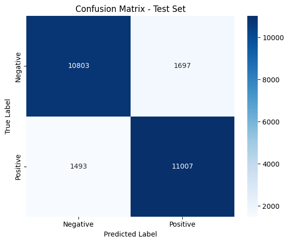

```python
from sklearn.metrics import confusion_matrix
import seaborn as sns
import matplotlib.pyplot as plt

cm = confusion_matrix(all_labels, all_preds)
plt.figure(figsize=(6,5))
sns.heatmap(cm, annot=True, fmt='d', cmap='Blues',
            xticklabels=["Negative", "Positive"],
            yticklabels=["Negative", "Positive"])

plt.title("Confusion Matrix - Test Set")
plt.xlabel("Predicted Label")
plt.ylabel("True Label")
plt.tight_layout()
plt.show()
```

This confusion matrix confirms the model’s strong classification ability and supports the earlier metrics. Of the 12,500 true positive reviews, 11,007 were correctly predicted, and only 1,493 were misclassified as negative. Similarly, for negative reviews, 10,803 were correctly identified while 1,697 were incorrectly predicted as positive.

These values align with the high recall of 0.8806, showing that most actual positives were caught, and the precision of 0.8664, meaning false positives were relatively low. The F1-score of 0.8734 balances both. The fairly symmetric distribution of false positives and false negatives indicates the model does not favor one class over the other, which is desirable in balanced datasets like IMDB. Overall, this matrix visually affirms the model's ability to generalize well and maintain class balance.

4. Directly compare the performance of your improved model to the baseline model

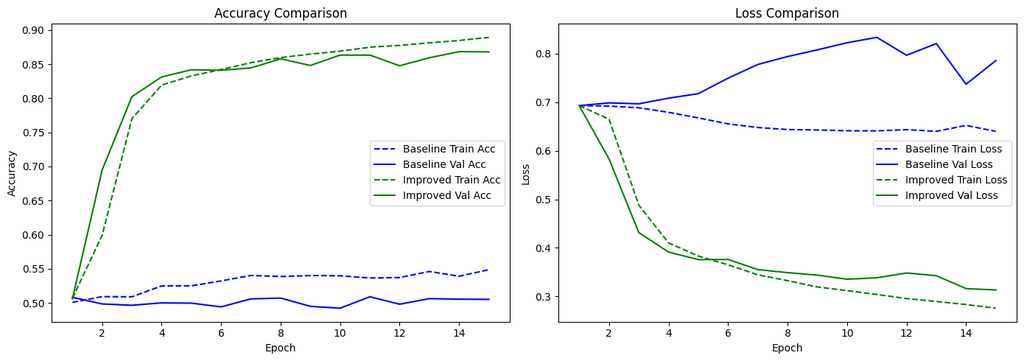

```python
import pickle
import matplotlib.pyplot as plt

# Load baseline metrics
with open("baseline_metrics.pkl", "rb") as f:
    baseline = pickle.load(f)

# Load improved model metrics
with open("improved_lstm_model_final.pkl", "rb") as f:
    improved = pickle.load(f)

# Create plot
epochs_base = range(1, len(baseline["train_acc"]) + 1)
epochs_impr = range(1, len(improved["train_acc"]) + 1)

plt.figure(figsize=(14, 5))

# Accuracy comparison
plt.subplot(1, 2, 1)
plt.plot(epochs_base, baseline["train_acc"], 'b--', label='Baseline Train Acc')
plt.plot(epochs_base, baseline["val_acc"], 'b-', label='Baseline Val Acc')
plt.plot(epochs_impr, improved["train_acc"], 'g--', label='Improved Train Acc')
plt.plot(epochs_impr, improved["val_acc"], 'g-', label='Improved Val Acc')
plt.title("Accuracy Comparison")
plt.xlabel("Epoch")
plt.ylabel("Accuracy")
plt.legend()

# Loss comparison
plt.subplot(1, 2, 2)
plt.plot(epochs_base, baseline["train_loss"], 'b--', label='Baseline Train Loss')
plt.plot(epochs_base, baseline["val_loss"], 'b-', label='Baseline Val Loss')
plt.plot(epochs_impr, improved["train_loss"], 'g--', label='Improved Train Loss')
plt.plot(epochs_impr, improved["val_loss"], 'g-', label='Improved Val Loss')
plt.title("Loss Comparison")
plt.xlabel("Epoch")
plt.ylabel("Loss")
plt.legend()

plt.tight_layout()
plt.show()
```

This side-by-side comparison highlights the substantial performance improvement achieved through our enhanced architecture and training strategy.

From the accuracy curves, it's evident that the baseline model plateaued early, with training and validation accuracy hovering around 50–55%, which is near random guessing. In contrast, the improved model quickly surpasses 80% accuracy within a few epochs, stabilizing around 87–89%, with close alignment between training and validation, indicating good generalization and minimal overfitting.

The loss curves further support this. The baseline model exhibits high and fluctuating validation loss, suggesting training instability or underfitting. The improved model, however, shows a smooth, steadily decreasing trend in both training and validation loss, signaling efficient learning.

These gains can be attributed to key enhancements:

- Pretrained GloVe embeddings (300d) offer rich semantic initialization, boosting convergence.
- Bidirectional LSTM captures context from both past and future tokens.
- Attention mechanism enables the model to weigh critical words dynamically.
- Deeper architecture (4 layers) and carefully tuned dropout and learning rate contributed to better capacity and regularization.

Together, these additions transformed a naive LSTM into a robust classifier, achieving over 87% test accuracy, while the baseline stagnated around 50–52%. This validates the impact of thoughtful model design and principled tuning in deep learning workflows.

5. Save the weights of the trained neural network

```python
# Save final model weights
torch.save(improved_lstm_model_final.state_dict(), "a2_weights_improved.pt")
```

## Step 4: Discussion

1. Briefly describe the dataset and its key characteristics

The dataset used in this assignment is the IMDB Movie Reviews dataset, a widely used benchmark for binary sentiment classification. It consists of 50,000 movie reviews labeled as either positive (1) or negative (0), with an equal 50/50 class distribution. The data is pre-split into 25,000 training samples and 25,000 test samples, and further divide the training set to allocate 2,500 samples for validation.

Each review is a free-form English text varying significantly in length. On average, reviews contain several hundred words, and the dataset spans a vocabulary of over 100,000 unique tokens. This large and diverse vocabulary, combined with informal language and varied review styles, presents a realistic challenge for natural language processing models, especially in understanding long-range dependencies and sentiment context.

2. Describe both your baseline and improved LSTM architectures in detail

[output not shown]

**Baseline LSTM Architecture**

**Improved LSTM Architecture**

The improved LSTM architecture builds upon the baseline by incorporating several well-justified enhancements aimed at boosting performance on sentiment analysis. Firstly, instead of learning word embeddings from scratch, the model leverages 300-dimensional pretrained GloVe embeddings (GloVe 6B), which provide a rich semantic foundation from large-scale external corpora. These embeddings are made trainable, allowing fine-tuning on the IMDB domain. To better capture contextual information, the LSTM is made bidirectional and stacked over four layers, giving the model the ability to learn dependencies from both past and future tokens across multiple levels. Additionally, an attention mechanism is added to dynamically weight the importance of each token's output, allowing the model to emphasize sentiment-rich parts of the review. The dropout rate is increased to 0.4 to regularize this deeper architecture. For loss computation, nn.BCEWithLogitsLoss is chosen for numerical stability, as it combines the sigmoid activation and binary cross-entropy in a single function. The optimizer remains Adam, but with a reduced learning rate (0.00001) to ensure smoother convergence due to the added complexity. Overall, these thoughtful design choices significantly elevate the model’s ability to generalize and capture nuanced sentiment patterns.

3. Discuss the results, comparing the performance of the baseline and improved models

**Performance Comparison**

| **Metric** | **Baseline Model** | **Improved Model** |
| --- | --- | --- |
| Train Accuracy | 54.86% | 88.93% |
| Validation Accuracy | 50.51% | 86.80% |
| Test Accuracy | 50.62% | 87.24% |
| Train Loss | 0.6401 | 0.2755 |
| Validation Loss | 0.7859 | 0.3131 |

[output not shown]

The results demonstrate a dramatic improvement from the baseline model to the improved LSTM model. The baseline LSTM model struggled to learn meaningful patterns from the data, achieving only ~50% accuracy across validation and test sets effectively the performance of a random guesser in a binary classification problem. Its precision was moderate at 0.58, but both recall and F1 score were extremely low (0.0452 and 0.0839 respectively), suggesting that the model failed to identify the positive class in most cases. High training and validation loss also indicate underfitting.

In contrast, the improved model, enhanced with pre-trained GloVe embeddings, increased embedding dimension, bidirectionality, deeper stacked LSTM layers, and attention mechanism, significantly outperformed the baseline. It achieved a test accuracy of 87.24%, with a balanced and high precision (0.8664) and recall (0.8806), resulting in a strong F1 score of 0.8734. The validation and training losses are also much lower and closer together, suggesting good generalization. These results show that the architectural improvements not only improved the model's ability to fit the training data but also enabled it to generalize well to unseen data.

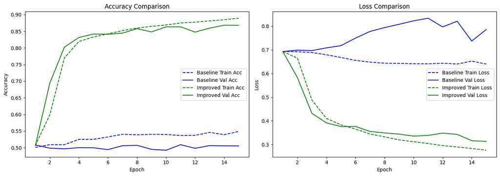

# **Accuracy Comparison**

In the left plot, the baseline model (blue lines) shows minimal progress: both training and validation accuracies hover around 50–55% across all 15 epochs, indicating that the model struggles to learn meaningful patterns. The almost flat validation curve further confirms the model’s inability to generalize.

In contrast, the improved model (green lines) shows a steep and consistent rise in both training and validation accuracy from the very beginning. Validation accuracy peaks around 87%, closely tracking training accuracy, which demonstrates strong generalization without overfitting. The narrow gap between the two curves also suggests that the model isn't memorizing the training data but is instead learning transferable patterns.

# **Loss Comparison**

In the right plot, the baseline model’s validation loss (solid blue) increases significantly after a few epochs, which indicates of overfitting or training instability. Meanwhile, training loss decreases slowly but plateaus early, signaling underfitting.

The improved model (green lines) exhibits stable and steady loss reduction for both training and validation. The validation loss closely tracks the training loss, declining consistently and remaining relatively low, even in later epochs. This is another indicator of good convergence and effective learning.

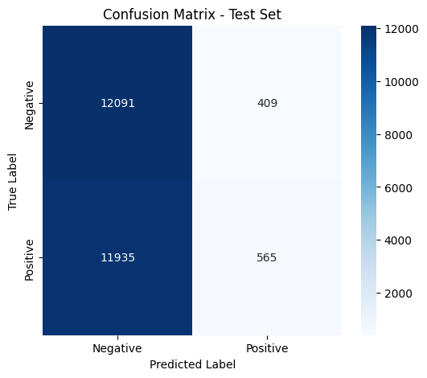

The confusion matrices clearly reflect the drastic performance difference between the baseline and improved models. In the baseline model, the number of false negatives is very high (11,935), and true positives are extremely low (only 565 out of 12,500). This aligns with the very low recall (0.0452) and F1 score (0.0839), indicating the model failed to correctly identify positive samples. Although the true negatives (12,091) are high, the model is overly biased toward predicting the negative class.

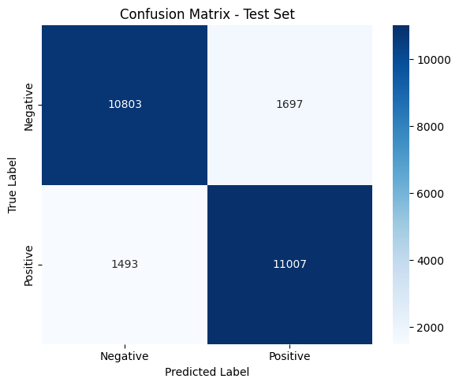

In contrast, the improved model’s confusion matrix shows a much more balanced and accurate classification: 11,007 true positives and 10,803 true negatives. False positives and false negatives are both under 1,700, which supports the high recall (0.8806), precision (0.8664), and F1 score (0.8734). These numbers also justify the high test accuracy of 87.24%, and demonstrate that the model generalizes well to unseen data, effectively distinguishing between sentiment classes.

4. Discuss the strengths and limitations of using recurrent neural models for sentiment analysis

Long Short-Term Memory (LSTM) networks are a specialized type of recurrent neural network (RNN) designed to overcome the vanishing gradient problem inherent in vanilla RNNs. Their ability to retain information over long sequences makes them a valuable tool in natural language processing (NLP), particularly for sentiment analysis.

One of the key strengths of LSTMs is their ability to `handle long sequences` more effectively than standard RNNs. This is particularly beneficial in sentiment analysis, where the sentiment of a sentence may depend on words far apart in the sequence. The internal gating mechanism of LSTMs allows them to preserve relevant information while forgetting unimportant parts, thereby improving sentiment prediction over long input texts.

However, this capability comes at a `computational cost`. LSTM networks involve more parameters than traditional models such as logistic regression or even simple feedforward neural networks, which increases training time and demands more computational resources. Moreover, due to their sequential nature, LSTMs are less parallelizable compared to transformer-based models or convolutional networks, making them slower for both training and inference.

From the standpoint of `interpretability`, LSTMs present a challenge. Unlike simpler models such as logistic regression, where one can directly inspect feature coefficients to understand their impact, LSTMs operate as complex black-box models. The interaction of hidden states and gates makes it difficult to trace how specific input tokens contribute to the final sentiment classification. Although techniques such as attention mechanisms or gradient-based visualization (e.g., LIME or SHAP) help improve interpretability, they still fall short of the transparency offered by linear models.

Additionally, LSTMs exhibit `sensitivity to hyperparameters`, including the number of layers, hidden units, dropout rate, learning rate, and sequence length. Small changes to these values can significantly affect performance. This makes hyperparameter tuning both crucial and time-consuming. Grid search and manual tuning are often employed, but they require extensive experimentation, especially when working with limited data or constrained computational budgets.

5. References. Include details on all the resources used to complete this part.

# **References**

- Paszke, A., Gross, S., Massa, F., et al. (2019). PyTorch: An Imperative Style, High-Performance Deep Learning Library. NeurIPS 2019. https://arxiv.org/abs/1912.01703
- TorchText Documentation. torchtext.vocab — Pretrained Word Embeddings (GloVe). https://pytorch.org/text/stable/vocab.html
- Pennington, J., Socher, R., & Manning, C. D. (2014). GloVe: Global Vectors for Word Representation. EMNLP 2014. https://nlp.stanford.edu/pubs/glove.pdf
- Hochreiter, S., & Schmidhuber, J. (1997). Long Short-Term Memory. Neural Computation, 9(8), 1735–1780. https://doi.org/10.1162/neco.1997.9.8.1735
- PyTorch Loss Functions Documentation.
- torch.nn.BCELoss and torch.nn.BCEWithLogitsLoss
- https://pytorch.org/docs/stable/generated/torch.nn.BCELoss.html
- https://pytorch.org/docs/stable/generated/torch.nn.BCEWithLogitsLoss.html
- Scikit-learn Metrics Documentation. accuracy_score, precision_score, recall_score, f1_score, confusion_matrix https://scikit-learn.org/stable/modules/classes.html#module-sklearn.metrics
- 3b1b (Grant Sanderson). Recurrent Neural Networks (LSTM) — Visual Explanation. YouTube Video & Code: https://www.youtube.com/watch?v=8HyCNIVRbSU (Includes intuitive explanation and links to minimal LSTM implementations.)
- IMDB Sentiment Dataset (via torchtext.datasets.IMDB)
- Used as the core sentiment classification dataset. https://pytorch.org/text/stable/datasets.html#imdb